# Storminess analysis: full corrected framework

Author

Francesco Lucano

# Start here

This notebook continues from the **existing monthly NetCDF products** of `reynolds_decomposition.qmd`. It does not download ERA5, filter winds, or rerun the Reynolds decomposition. It contains the implemented scope of the original framework: monthly preparation and diagnostics, energy characterization, annual and seasonal Pan-Arctic trends, and spatial trend maps for five metrics. The former roadmap’s regional and attribution studies were not implemented; this revision does not present them as completed analyses.

Read and run the notebook from top to bottom. Each stage explains its purpose, the objects it creates, and how to interpret the outputs. Start in `setup-environment`: check **DATA_DIRECTORY** and **LEGACY_DATA_DIR**. All corrected tables, figures and caches are written into separate directories. The input NetCDF files and old analysis outputs are read only.

| Stage | What happens | Main object/output |
| --- | --- | --- |
| 0. Setup and shared functions | Paths, controls, date and statistical helpers | One configuration chunk |
| 1. Read and verify data | Decode actual months, align grids, area-weight monthly fields | `storm_df`, input audit |
| 2. Understand variability | Summary statistics, ACF/PACF, STL, climatologies | Diagnostic CSVs and figures |
| 3. Describe energy | Monthly Reynolds energy partition and EKE comparison | Original Phase 2 figures |
| 4. Estimate domain trends | Zhang slopes/tests and matching residual bootstrap intervals | 8 annual and 32 seasonal rows |
| 5. Examine spatial trends | Check/reuse cached local tests; calculate BH; draw maps | 25-field local/BH summary |
| 6. Review outputs | Session details and a file inventory | Submission review checklist |

**What has changed scientifically?** The reported Zhang slope is retained, but its bootstrap now repeats the same estimator. Blocks are selected from fitted residuals. The confidence intervals must therefore be regenerated. BH results are calculated from the actual local p-values rather than assumed to be zero. Rejection fractions are descriptive and are not labelled field-significance tests. Complete annual/seasonal trend periods remain 1958–2025.

**A boundary correction:** `storm_df` includes December 1957 for DJF 1958. Calendar-month diagnostics and annual climatologies use January 1958–December 2025 (816 months). Seasonal climatologies use 68 complete seasons, so DJF uses December 1957–February 2025 and excludes December 2025. Small changes from old summary values that mixed these windows are expected.

**Execution status:** all code chunks were parsed by R. The date, DJF and BH self-checks were executed. A synthetic-series test using `zyp`, `boot` and `blocklength` checked preservation of the original point estimate/p-value, finite bootstrap output and reproducibility with a fixed seed. These checks used a lightweight R runtime, not the actual ERA5 data. NetCDF processing, full spatial execution and figure layout must still be verified on the local R installation; no full ERA5 run is claimed here.

# 0. Configure the analysis

## 0.1 Environment and settings

Keep all routine edits here. Packages are checked, not installed automatically. If packages are missing, run the printed installation command in the R console and rerun this chunk. Python/reticulate is unnecessary for this downstream R analysis; the original Python preprocessing environment is unaffected.

`ALLOW_SPATIAL_RECOMPUTE = FALSE` prevents an unexpected full spatial rerun. The old cache is first checked against actual months, coordinates, and 24 sampled grid points in every variable/period. Passing these checks supports reuse but cannot reconstruct missing historical provenance. If a cache is incompatible, the notebook stops with a specific message; it does not guess.

```r
# Central settings: paths first, then execution controls and statistical choices.
required_packages <- c("here", "tidyverse", "glue", "lubridate", "ncdf4",
  "stars", "sf", "rnaturalearth", "rnaturalearthdata", "zoo", "boot", "zyp",
  "blocklength", "patchwork", "viridis", "RColorBrewer", "future", "furrr", "knitr")
missing_packages <- required_packages[!vapply(required_packages, requireNamespace,
                                             logical(1), quietly=TRUE)]
if (length(missing_packages)) stop(paste0("Install these packages in the R console:\n",
  "install.packages(c(", paste(sprintf('"%s"', missing_packages), collapse=", "), "))"),
  call.=FALSE)
invisible(lapply(required_packages, library, character.only=TRUE))
```

```
here() starts at C:/Users/franc/Documents/Master/Task_1_storminess/svalbard-storminess-climatology
```

```r
knitr::opts_chunk$set(fig.width=12, fig.height=7, dpi=150)

# EDIT THESE TWO INPUT LOCATIONS to match the existing project on your computer.
DATA_DIRECTORY <- here::here("Data", "processed")
LEGACY_DATA_DIR <- file.path(DATA_DIRECTORY, "analysis_ready")
# If NetCDFs are elsewhere, DATA_DIRECTORY can instead be an absolute path,
# e.g. "E:/ERA5_data/processed/output". LEGACY_DATA_DIR must still point to
# the folder containing the existing Phase3_4_Spatial_Results.RData.

# New outputs: original inputs, caches and figures are not overwritten.
OUTPUT_DATA_DIR <- here::here("Data", "processed", "analysis_corrected")
FIGURES_DIR <- here::here("Figures_corrected")
FIG_PHASE1 <- file.path(FIGURES_DIR,"Phase1_Diagnostics")
FIG_PHASE2 <- file.path(FIGURES_DIR,"Phase2_Energy_Budget")
FIG_PHASE3 <- file.path(FIGURES_DIR,"Phase3_Trends")
TREND_CACHE_DIR <- file.path(OUTPUT_DATA_DIR,"trend_cache")
for (d in c(OUTPUT_DATA_DIR,FIG_PHASE1,FIG_PHASE2,FIG_PHASE3,TREND_CACHE_DIR))
  dir.create(d,recursive=TRUE,showWarnings=FALSE)

METRICS_FILE <- file.path(DATA_DIRECTORY,"ERA5_storminess_metrics_monthly.nc")
TKE_FILE <- file.path(DATA_DIRECTORY,"ERA5_TKE_monthly.nc")
MKE_FILE <- file.path(DATA_DIRECTORY,"ERA5_MKE_monthly.nc")
EKE_BUDGET_FILE <- file.path(DATA_DIRECTORY,"ERA5_EKE_budget_monthly.nc")
FRAMEWORK_VERSION <- "submission-corrected-1.0"

# Execution controls. The default runs all figures and domain-mean trends.
MAKE_FIGURES <- TRUE
RUN_SPATIAL <- TRUE
CHECK_LEGACY_SPATIAL_CACHE <- TRUE
ALLOW_SPATIAL_RECOMPUTE <- FALSE
FORCE_SPATIAL_RECOMPUTE <- FALSE
FORCE_TREND_RECOMPUTE <- FALSE
SPATIAL_WORKERS <- 1L       # 1 avoids parallel memory copies; increase cautiously
SPATIAL_BATCH_POINTS <- 2000L
READ_MONTHS <- 12L          # memory-bounded NetCDF reads for monthly preparation
options(future.globals.maxSize=1024^3)

ARCTIC_LAT_THRESHOLD <- 60
ANNUAL_START_YEAR <- 1958L
ANALYSIS_END_YEAR <- 2025L
MONTH_START <- as.Date("1957-12-01")
MONTH_END <- as.Date("2025-12-01")
REFERENCE_PERIOD <- c(1961L,1990L)
SEASONS <- c("DJF","MAM","JJA","SON")
SEASON_NAMES <- c(DJF="Winter (DJF)",MAM="Spring (MAM)",JJA="Summer (JJA)",SON="Autumn (SON)")
ALPHA <- 0.05             # nominal domain/local test level; CI tail probability
ALPHA_LOCAL <- ALPHA
FDR_Q <- 0.10             # BH per variable-period family; separate from ALPHA
N_BOOT <- 2000L
BOOT_SEED <- 42L
B_FALLBACK <- 3L          # explicit fallback, recorded in each results row
DECADES <- 10
BASE_SIZE <- 14
TITLE_SIZE <- 18
SUBTITLE_SIZE <- 12

METRIC_NAMES <- c(
  "eke_synoptic_mean",  # PRIMARY: Monthly mean synoptic-scale EKE (eq. 2.12)
  "eke_p90",            # 90th percentile of 6-hourly EKE within each month
  "eke_p95",            # 95th percentile
  "eke_p99",            # 99th percentile (extreme storm intensity)
  "exceed_p95_freq"     # Fraction of timesteps exceeding 1961-1990 P95 threshold
)

ENERGY_VARS <- c(
  "tke",                # Total Kinetic Energy (eq. 2.7)
  "mke",                # Mean Kinetic Energy  (eq. 2.8)
  "eke_budget"          # Budget-derived EKE, all sub-monthly variance (eq. 2.9)
)

ALL_VARS <- c(METRIC_NAMES, ENERGY_VARS)

# Labels for figures (native plotmath)
VAR_LABELS <- c(
  "eke_synoptic_mean" = '"Mean EKE"[synoptic]~(m^2/s^2)',
  "eke_p90"           = '"P90 EKE"~(m^2/s^2)',
  "eke_p95"           = '"P95 EKE"~(m^2/s^2)',
  "eke_p99"           = '"P99 EKE"~(m^2/s^2)',
  "exceed_p95_freq"   = '"P95 Exceedance Frequency"',
  "tke"               = '"TKE"~(m^2/s^2)',
  "mke"               = '"MKE"~(m^2/s^2)',
  "eke_budget"        = '"EKE"[budget]~(m^2/s^2)'
)

# Simple labels for table output (plain text, no Unicode superscripts)
VAR_LABELS_PLAIN <- c(
  "eke_synoptic_mean" = "Mean EKE_synoptic",
  "eke_p90"           = "P90 EKE",
  "eke_p95"           = "P95 EKE",
  "eke_p99"           = "P99 EKE",
  "exceed_p95_freq"   = "P95 Exceedance Freq.",
  "tke"               = "TKE",
  "mke"               = "MKE",
  "eke_budget"        = "EKE_budget"
)

# Short plotmath labels (no units) — for embedding variable names in compound
# plot titles, e.g. paste0('"STL Decomposition: "~', VAR_LABELS_SHORT[["eke_synoptic_mean"]])
# Strip everything from the first "~(" onward (removes the "(m^2/s^2)" suffix).
VAR_LABELS_SHORT <- sub("~\\(.*\\)$", "", VAR_LABELS)



METRIC_COLORS <- c(
  "eke_synoptic_mean" = "#000000",  # Black
  "eke_p90"           = "#56B4E9",  # Sky blue
  "eke_p95"           = "#009E73",  # Teal green
  "eke_p99"           = "#332288",  # Deep Indigo
  "exceed_p95_freq"   = "#0072B2"   # Blue
)

ENERGY_COLORS <- c(
  "tke"        = "#E69F00",   # Golden Orange
  "mke"        = "#D55E00",   # Vermillion
  "eke_budget" = "#CC79A7"    # Reddish Purple/Pink
)

ALL_COLORS <- c(METRIC_COLORS, ENERGY_COLORS)

SEASON_COLORS <- c(
  "DJF" = "#4575B4",  # Blue
  "MAM" = "#91CF60",  # Green
  "JJA" = "#D73027",  # Red
  "SON" = "#A6611A"   # Warm rust
)



SPATIAL_VARS <- METRIC_NAMES
stopifnot(ALPHA>0,ALPHA<1,FDR_Q>0,FDR_Q<1,N_BOOT>=200L,
          B_FALLBACK>=1L,B_FALLBACK<(ANALYSIS_END_YEAR-ANNUAL_START_YEAR+1L),
          READ_MONTHS>=1L,SPATIAL_WORKERS>=1L,SPATIAL_BATCH_POINTS>=1L)
if (FORCE_SPATIAL_RECOMPUTE && !ALLOW_SPATIAL_RECOMPUTE)
  stop("FORCE_SPATIAL_RECOMPUTE requires ALLOW_SPATIAL_RECOMPUTE=TRUE.")
for (f in c(METRICS_FILE,TKE_FILE,MKE_FILE,EKE_BUDGET_FILE))
  if (!file.exists(f)) stop(paste("Input not found:",f,"-- adjust DATA_DIRECTORY."))
cat("Inputs:",DATA_DIRECTORY,"\nCorrected tables:",OUTPUT_DATA_DIR,
    "\nCorrected figures:",FIGURES_DIR,"\n")
```

```
Inputs: C:/Users/franc/Documents/Master/Task_1_storminess/svalbard-storminess-climatology/Data/processed
Corrected tables: C:/Users/franc/Documents/Master/Task_1_storminess/svalbard-storminess-climatology/Data/processed/analysis_corrected
Corrected figures: C:/Users/franc/Documents/Master/Task_1_storminess/svalbard-storminess-climatology/Figures_corrected
```

## 0.2 Shared functions: read once, reuse throughout

A **function** gives a name to a repeated task. Defining it does not run the analysis: the later chunks supply its input and use its result. The time helper reads CF units from each file. It truncates sub-millisecond precision in the origin for month identification, avoiding rounding an end-of-month timestamp into the next month. Dates must match every expected month, in order.

`read_cube()` uses dimension **names**, rather than guessing from array sizes. `prepare_variable()` reads a few months at a time and uses cosine-latitude weights. Missing Arctic cells stop the run so that the geographical footprint does not silently change. The old NetCDF name `eke_mean` is accepted as an in-memory alias for `eke_synoptic_mean`.

```r
# Each helper has one job. Functions are defined here, then called below.
# They do not open or alter the preprocessing wind files.

assert_that <- function(ok, message) {
  if (!isTRUE(ok)) stop(message, call. = FALSE)
}

# A small fingerprint records settings/data in caches without hashing a huge
# NetCDF file on every run. File identity below uses path, size and mtime.
object_hash <- function(x) {
  f <- tempfile(fileext = ".rds")
  on.exit(unlink(f), add = TRUE)
  saveRDS(x, f, version = 2)
  unname(tools::md5sum(f))
}
file_identity <- function(path) {
  info <- file.info(path)
  assert_that(!is.na(info$size), paste("Missing input:", path))
  list(path = normalizePath(path, winslash = "/", mustWork = TRUE),
       bytes = unname(info$size), modified = as.numeric(info$mtime))
}
write_rds <- function(x, path) {
  # Write to a temporary sibling first. A failed calculation never writes a
  # partially built object into its final cache. Only corrected caches change.
  tmp <- tempfile(tmpdir = dirname(path), fileext = ".rds")
  on.exit(unlink(tmp), add = TRUE)
  saveRDS(x, tmp)
  assert_that(file.copy(tmp, path, overwrite = TRUE), paste("Cannot save:", path))
}

# ---- CF time: decode the FILE coordinate; never invent an 817-row sequence ----
decode_months <- function(raw, units, calendar = "standard") {
  assert_that(calendar %in% c("standard", "gregorian", "proleptic_gregorian"),
              paste("Unsupported calendar:", calendar))
  match <- regexec("^(days|hours|minutes|seconds|milliseconds|microseconds) since (.+)$",
                   trimws(units))
  parts <- regmatches(trimws(units), match)[[1]]
  assert_that(length(parts) == 3L, paste("Unsupported time units:", units))
  factor_sec <- c(days = 86400, hours = 3600, minutes = 60, seconds = 1,
                  milliseconds = 0.001, microseconds = 0.000001)[parts[2]]
  origin <- sub("T", " ", parts[3], fixed = TRUE)
  origin <- sub("( UTC|Z| ?\\+00:00)$", "", origin)
  if (grepl("^\\d{4}-\\d{2}-\\d{2}$", origin)) origin <- paste(origin, "00:00:00")
  assert_that(grepl("^\\d{4}-\\d{2}-\\d{2} \\d{2}:\\d{2}:\\d{2}(\\.\\d+)?$", origin),
              paste("Unrecognized time origin:", origin))
  # pandas end_time is 23:59:59.999999999. POSIXct cannot keep nanoseconds.
  # Truncate the origin's fraction to milliseconds, rather than rounding it
  # into the next month. This changes <1 ms and is used ONLY to identify months.
  origin <- sub("(\\.\\d{3})\\d+", "\\1", origin)
  t0 <- as.POSIXct(origin, format = "%Y-%m-%d %H:%M:%OS", tz = "UTC")
  assert_that(!is.na(t0) && all(is.finite(raw)), "Invalid time coordinate.")
  stamps <- t0 + as.numeric(raw) * factor_sec
  as.Date(format(stamps, "%Y-%m-01", tz = "UTC"))
}

read_metadata <- function(path) {
  nc <- ncdf4::nc_open(path)
  on.exit(ncdf4::nc_close(nc), add = TRUE)
  raw <- ncdf4::ncvar_get(nc, "time")
  units <- ncdf4::ncatt_get(nc, "time", "units")$value
  ca <- ncdf4::ncatt_get(nc, "time", "calendar")
  calendar <- if (isTRUE(ca$hasatt)) ca$value else "standard"
  dates <- decode_months(raw, units, calendar)
  expected <- seq(MONTH_START, MONTH_END, by = "month")
  assert_that(identical(as.character(dates), as.character(expected)),
    paste(basename(path), "must contain each month, in order, from",
          MONTH_START, "to", MONTH_END, "with no duplicates or gaps."))
  lat <- ncdf4::ncvar_get(nc, "latitude")
  lon <- ncdf4::ncvar_get(nc, "longitude")
  assert_that(length(lat) > 1L && length(lon) > 1L &&
                all(is.finite(lat)) && all(is.finite(lon)), "Invalid spatial coordinates.")
  assert_that(all(diff(lat) > 0) || all(diff(lat) < 0), "Latitude must be monotonic.")
  assert_that(all(diff(lon) > 0), "Longitude must be increasing.")
  assert_that(max(abs(diff(lon) - median(diff(lon)))) < 1e-5 &&
                abs(length(lon) * median(diff(lon)) - 360) < 1e-3,
              "Expected a complete, regular longitude grid without a duplicate endpoint.")
  assert_that(max(abs(abs(diff(lat)) - median(abs(diff(lat))))) < 1e-5,
              "Cosine weighting here requires regular latitude spacing.")
  list(path = path, raw_time = raw, time_units = units, dates = dates,
       calendar = calendar, lat = lat, lon = lon, variables = names(nc$var),
       identity = file_identity(path))
}

resolve_variable <- function(nc, variable) {
  # Accept the old name in memory: no rename/overwrite of the source NetCDF.
  actual <- if (variable == "eke_synoptic_mean" &&
                 !variable %in% names(nc$var) && "eke_mean" %in% names(nc$var))
    "eke_mean" else variable
  assert_that(actual %in% names(nc$var), paste("Missing variable:", variable))
  actual
}
read_cube <- function(nc, variable, time_start = 1L, time_count = -1L) {
  actual <- resolve_variable(nc, variable)
  dn <- vapply(nc$var[[actual]]$dim, function(d) d$name, character(1))
  target <- c("time", "latitude", "longitude")
  assert_that(length(dn) == 3L && setequal(dn, target),
              paste(actual, "must have time, latitude and longitude dimensions."))
  start <- rep(1L, 3); count <- rep(-1L, 3)
  start[match("time", dn)] <- time_start
  count[match("time", dn)] <- time_count
  arr <- ncdf4::ncvar_get(nc, actual, start = start, count = count,
                          collapse_degen = FALSE)
  aperm(arr, match(target, dn)) # now ALWAYS [time, latitude, longitude]
}

month_index <- function(dates) {
  y <- as.integer(format(dates, "%Y")); m <- as.integer(format(dates, "%m"))
  tibble(date = dates, year = y, month = m,
    season = c("DJF", "DJF", "MAM", "MAM", "MAM", "JJA",
               "JJA", "JJA", "SON", "SON", "SON", "DJF")[m],
    season_year = y + as.integer(m == 12L))
}
period_indices <- function(index, period) {
  years <- ANNUAL_START_YEAR:ANALYSIS_END_YEAR
  ids <- lapply(years, function(y) {
    if (period == "Annual") which(index$year == y)
    else which(index$season == period & index$season_year == y)
  })
  assert_that(all(lengths(ids) == if (period == "Annual") 12L else 3L),
              paste("Incomplete monthly coverage for", period))
  ids
}
aggregate_series <- function(x, index, period) {
  assert_that(all(is.finite(x)), "Missing/non-finite monthly values: aggregation stopped.")
  vapply(period_indices(index, period), function(i) mean(x[i]), numeric(1))
}

# Stream a few months at a time. This retains all original metrics/maps without
# keeping five full 817-month global arrays in RAM simultaneously.
prepare_variable <- function(meta, variable, keep_map = FALSE) {
  nc <- ncdf4::nc_open(meta$path)
  on.exit(ncdf4::nc_close(nc), add = TRUE)
  ai <- which(meta$lat >= ARCTIC_LAT_THRESHOLD & meta$lat < 90)
  assert_that(length(ai) > 0, "No grid points in the Arctic domain.")
  weights <- matrix(cos(meta$lat[ai] * pi/180), length(ai), length(meta$lon))
  weighted <- unweighted <- coverage <- numeric(length(meta$dates))
  total <- matrix(0, length(meta$lat), length(meta$lon))
  counts <- total
  want_seasons <- keep_map && variable %in% c("eke_synoptic_mean", "eke_p95")
  seasonal_total <- setNames(lapply(SEASONS, function(s) total), SEASONS)
  seasonal_counts <- seasonal_total
  mi <- month_index(meta$dates)
  for (first in seq(1L, length(meta$dates), by = READ_MONTHS)) {
    n <- min(READ_MONTHS, length(meta$dates) - first + 1L)
    a <- read_cube(nc, variable, first, n)
    assert_that(!any(is.infinite(a)), paste("Infinite values in", variable))
    finite <- a[is.finite(a)]
    assert_that(length(finite) > 0 && min(finite) >= -1e-6,
                paste("Missing or negative energy/frequency in", variable))
    if (variable == "exceed_p95_freq")
      assert_that(max(finite) <= 1 + 1e-6, "Exceedance fractions exceed one.")
    for (j in seq_len(n)) {
      k <- first + j - 1L
      slice <- a[j, ai, , drop = FALSE]
      dim(slice) <- dim(weights)
      valid <- is.finite(slice)
      # A changing mask changes the region represented by a time series.
      # Stop rather than silently discard missing cells. ERA5 is expected complete.
      assert_that(all(valid), paste("Missing Arctic cells:", variable, meta$dates[k],
                                    "Check the input; no automatic preprocessing is run."))
      weighted[k] <- weighted.mean(slice, weights)
      unweighted[k] <- mean(slice)
      coverage[k] <- sum(weights[valid]) / sum(weights)
      if (want_seasons && mi$season_year[k] >= ANNUAL_START_YEAR &&
          mi$season_year[k] <= ANALYSIS_END_YEAR) {
        seas <- mi$season[k]; field <- a[j,,]; good <- is.finite(field)
        seasonal_total[[seas]][good] <- seasonal_total[[seas]][good] + field[good]
        seasonal_counts[[seas]][good] <- seasonal_counts[[seas]][good] + 1L
      }
      if (keep_map && meta$dates[k] >= as.Date(paste0(ANNUAL_START_YEAR, "-01-01"))) {
        field <- a[j, , ]; good <- is.finite(field)
        total[good] <- total[good] + field[good]
        counts[good] <- counts[good] + 1L
      }
    }
  }
  climatology <- total / counts
  climatology[counts == 0] <- NA_real_
  list(weighted = weighted, unweighted = unweighted, coverage = coverage,
       climatology = if (keep_map) climatology else NULL,
       seasonal_climatology = if (want_seasons) setNames(lapply(SEASONS, function(s) {
         x <- seasonal_total[[s]] / seasonal_counts[[s]]
         x[seasonal_counts[[s]] == 0] <- NA_real_
         x
       }), SEASONS) else NULL)
}
```

## 0.3 Shared statistical functions

`zhang_fit()` preserves the original `zyp.zhang()` settings and computes the point estimate and PWMK p-value. It translates consecutive years to 1, 2, …, which changes the origin but not the slope. Constant series return zero trend and p = 1 explicitly.

`fit_with_mbb()` fits that same slope, computes a median intercept and residuals, selects a block length from the residuals, resamples residual blocks, adds back the fitted trend on the original years, and runs `zhang_fit()` again in **every** replicate. The 2.5th and 97.5th bootstrap percentiles form an approximate interval. `endcorr=TRUE` retains the original `tsboot()` default.

The interval assumes a useful linear-trend/residual model and approximately stationary residual dependence. It is not an exact inversion of the PWMK test, so disagreement between the CI and that test is exported for inspection. No claim of guaranteed finite-sample coverage is made.

```r
# One shared Zhang implementation: original point estimate and EVERY bootstrap
# replicate call this function, using the same yearly time axis and options.
zhang_fit <- function(y, years) {
  assert_that(length(y) == length(years) && length(y) >= 10L &&
                all(is.finite(y)) && all(is.finite(years)) && all(diff(years) == 1),
              "Zhang analysis requires finite observations on consecutive years.")
  if (length(unique(y)) == 1L)
    return(c(trend = 0, sig = 1, tau = 0, autocor = 0, nruns = 0))
  result <- zyp::zyp.zhang(y = y, x = years - years[1] + 1,
                          conf.intervals = FALSE,
                          preserve.range.for.sig.test = FALSE)
  assert_that(all(is.finite(result[c("trend", "sig", "tau")])) &&
                result["sig"] >= 0 && result["sig"] <= 1,
              "Zhang calculation returned an invalid slope or p-value.")
  result
}

get_block_length <- function(residuals) {
  # Select blocks from the residuals that will actually be resampled.
  # A trend in the original series should not determine residual block length.
  if (sd(residuals) < .Machine$double.eps)
    return(list(b = 1L, fallback = FALSE, reason = "constant residuals"))
  choice <- tryCatch({
    a <- blocklength::pwsd(residuals, round = TRUE, correlogram = FALSE)
    as.integer(a$BlockLength[1, "b_Circular"])
  }, error = function(e) NA_integer_)
  fallback <- length(choice) != 1L || !is.finite(choice) || choice < 1L ||
              choice >= length(residuals)
  list(b = if (fallback) B_FALLBACK else choice, fallback = fallback,
       reason = if (fallback) "PWSD unavailable or outside valid range" else "PWSD on residuals")
}

fit_with_mbb <- function(y, years, seed) {
  mk <- zhang_fit(y, years)
  beta <- unname(mk["trend"])
  t <- years - mean(years)
  center <- median(y - beta * t)
  residuals <- y - (center + beta * t)
  block <- get_block_length(residuals)
  # Percentile residual bootstrap: approximate intervals, conditional on the
  # fitted linear trend and residual dependence model. Not an exact MK inversion.
  set.seed(seed)
  replicate_count <- 0L
  ans <- boot::tsboot(
    tseries = residuals,
    statistic = function(r, ...) {
      # tsboot first evaluates the original residuals, then its replicates.
      replicate_count <<- replicate_count + 1L
      if (replicate_count > 1L && (replicate_count-1L) %% 250L == 0L) {
        cat("  Bootstrap replicates:",replicate_count-1L,"/",N_BOOT,"\n")
        flush.console()
      }
      y_star <- center + beta * t + as.numeric(r)
      unname(zhang_fit(y_star, years)["trend"])
    }, R = N_BOOT, l = block$b, sim = "fixed", endcorr = TRUE
  )
  draws <- as.numeric(ans$t)
  assert_that(length(draws) == N_BOOT && all(is.finite(draws)),
              "Bootstrap failed: invalid replicates are not silently discarded.")
  ci <- unname(quantile(draws, c(ALPHA/2, 1-ALPHA/2), type = 7))
  list(mk = mk, beta = beta, intercept = center - beta * mean(years),
       ci = ci, block = block, draws = draws,
       residual_rho1 = if (sd(residuals) > 0)
         as.numeric(acf(residuals, lag.max = 1, plot = FALSE)$acf[2]) else 0)
}

# BH is applied separately to each variable-period family. Missing tests are
# excluded explicitly. Rank one is sufficient, not necessary, for discoveries.
bh_field <- function(p, q = FDR_Q) {
  good <- is.finite(p)
  assert_that(all(p[good] >= 0 & p[good] <= 1), "Local p-values outside [0,1].")
  adjusted <- p * NA_real_
  if (any(good)) adjusted[good] <- p.adjust(p[good], method = "BH")
  list(p_bh = adjusted, sig_bh = adjusted <= q,
       n_tests = sum(good), n_discoveries = sum(adjusted <= q, na.rm = TRUE))
}
```

## 0.4 Small self-checks

```r
# These small checks test dates, season attribution and BH edge cases.
# They use synthetic inputs and do not read or change any ERA5 values.
a <- decode_months(c(0,31,59), "days since 1957-12-31 23:59:59.999999999")
assert_that(identical(as.character(a), c("1957-12-01","1958-01-01","1958-02-01")),
            "End-of-month decoding self-check failed.")
b <- decode_months(c(0,31*24,59*24), "hours since 1958-01-01 00:00:00")
assert_that(identical(as.character(b), c("1958-01-01","1958-02-01","1958-03-01")),
            "Hour-unit decoding self-check failed.")
i <- month_index(as.Date(c("1957-12-01","1958-01-01","1958-02-01")))
assert_that(all(i$season=="DJF" & i$season_year==1958), "DJF attribution self-check failed.")
# Higher ranks can trigger discoveries when rank one fails.
p <- c(0.0015,0.0016,rep(1,98))
assert_that(min(p) > 0.1/100 && bh_field(p,q=0.1)$n_discoveries==2,
            "BH step-up self-check failed.")
assert_that(bh_field(c(1.19e-7,rep(1,172799)),q=0.1)$n_discoveries>=1,
            "BH rank-one self-check failed.")
assert_that(bh_field(c(NA,0.5,0.9),q=0.1)$n_discoveries==0,
            "BH missing-value self-check failed.")
cat("Date, DJF and BH self-checks passed.\n")
```

```
Date, DJF and BH self-checks passed.
```

# 1. Prepare and validate the monthly data

**Input:** four existing monthly NetCDFs. **Output:** `storm_df` (817 months), `diagnostic_df` (816 calendar months), `annual_df` (68 years), `seasonal_df` (68 observations per season), and small spatial climatology matrices.

A month key allows the energy files’ month-end-at-midnight timestamps and the storminess file’s end-of-day timestamps to refer to the same month. Every file must independently pass the coverage check before its values are combined. Cosine weights account for shrinking cell areas towards the pole. Temporal means retain the original equal-month weighting; no daily-weighting change is introduced. The decomposition closure check is on the aligned domain means, not a claim that every individual grid-cell residual has been checked.

The new preparation cache records file path, size, modification time, domain and settings. This is a practical change detector, not a cryptographic audit of all NetCDF values. If input contents change while metadata are deliberately preserved, remove the corrected cache to rebuild it.

```r
# Inspect the actual months and coordinates of all four inputs before loading data.
input_paths <- c(metrics = METRICS_FILE, tke = TKE_FILE,
                 mke = MKE_FILE, eke_budget = EKE_BUDGET_FILE)
metadata <- lapply(input_paths, read_metadata)
reference <- metadata$metrics
for (name in names(metadata)) {
  m <- metadata[[name]]
  assert_that(identical(m$dates, reference$dates), paste(name, "month mismatch"))
  assert_that(isTRUE(all.equal(m$lat, reference$lat)) &&
                isTRUE(all.equal(m$lon, reference$lon)), paste(name, "grid mismatch"))
}
lat <- reference$lat; lon <- reference$lon
lat_arctic <- lat[lat >= ARCTIC_LAT_THRESHOLD & lat < 90]
time_dates <- reference$dates
index <- month_index(time_dates)
years_vec <- ANNUAL_START_YEAR:ANALYSIS_END_YEAR

# A metadata table makes raw units, month decoding and file identity reviewable.
input_audit <- bind_rows(lapply(names(metadata), function(n) {
  m <- metadata[[n]]
  tibble(input = n, path = m$identity$path, bytes = m$identity$bytes,
    modified = m$identity$modified, time_units = m$time_units,
    calendar = m$calendar, n_months = length(m$dates),
    first_month = as.character(min(m$dates)), last_month = as.character(max(m$dates)),
    n_lat = length(m$lat), n_lon = length(m$lon))
}))
write_csv(input_audit, file.path(OUTPUT_DATA_DIR, "Input_Audit.csv"))
print(knitr::kable(input_audit %>% select(input, n_months, first_month, last_month)))
```

```
|input      | n_months|first_month |last_month |
|:----------|--------:|:-----------|:----------|
|metrics    |      817|1957-12-01  |2025-12-01 |
|tke        |      817|1957-12-01  |2025-12-01 |
|mke        |      817|1957-12-01  |2025-12-01 |
|eke_budget |      817|1957-12-01  |2025-12-01 |
```

```r
prepare_signature <- object_hash(list(version = FRAMEWORK_VERSION,
  inputs = lapply(metadata, `[[`, "identity"), domain = ARCTIC_LAT_THRESHOLD,
  dates = time_dates, variables = ALL_VARS, climatology_start = ANNUAL_START_YEAR))
prepared_cache <- file.path(OUTPUT_DATA_DIR, "Prepared_Monthly.rds")
prepared <- if (file.exists(prepared_cache)) readRDS(prepared_cache) else NULL
if (is.null(prepared) || !identical(prepared$signature, prepare_signature)) {
  prepared <- list(signature = prepare_signature, variables = list())
  for (v in ALL_VARS) {
    cat("Reading and aggregating:", v, "\n")
    meta <- if (v %in% METRIC_NAMES) reference else metadata[[v]]
    prepared$variables[[v]] <- prepare_variable(meta, v, keep_map = v %in% METRIC_NAMES)
  }
  write_rds(prepared, prepared_cache)
} else cat("Reusing verified monthly preparation cache.\n")
```

```
Reusing verified monthly preparation cache.
```

```r
storm_df <- index
for (v in ALL_VARS) storm_df[[v]] <- prepared$variables[[v]]$weighted
storm_df <- storm_df %>% mutate(eke_fraction = eke_budget/tke,
                               mke_eke_ratio = mke/eke_budget)
# All nonseasonal climatologies/diagnostics use Jan 1958--Dec 2025 (816 months).
# December 1957 is retained only in storm_df to complete DJF 1958.
diagnostic_df <- storm_df %>% filter(year >= ANNUAL_START_YEAR, year <= ANALYSIS_END_YEAR)
climatology_maps_full <- lapply(prepared$variables[METRIC_NAMES], `[[`, "climatology")

ts_start <- c(ANNUAL_START_YEAR, 1)
ts_objects <- lapply(diagnostic_df[METRIC_NAMES], ts, start = ts_start, frequency = 12)
deseasonalize <- function(df, metric_col) {
  df[[metric_col]] - ave(df[[metric_col]], df$month, FUN = mean)
}
ts_objects_anom <- lapply(METRIC_NAMES, function(v)
  ts(deseasonalize(diagnostic_df, v), start = ts_start, frequency = 12))
names(ts_objects_anom) <- METRIC_NAMES
ts_objects_energy_anom <- lapply(ENERGY_VARS, function(v)
  ts(deseasonalize(diagnostic_df, v), start = ts_start, frequency = 12))
names(ts_objects_energy_anom) <- ENERGY_VARS

annual_df <- tibble(year = years_vec)
for (v in ALL_VARS) annual_df[[v]] <- aggregate_series(storm_df[[v]], index, "Annual")
seasonal_df <- bind_rows(lapply(SEASONS, function(seas) {
  out <- tibble(season = seas, season_year = years_vec)
  for (v in ALL_VARS) out[[v]] <- aggregate_series(storm_df[[v]], index, seas)
  out
}))
energy_annual <- annual_df %>% mutate(eke_fraction = eke_budget/tke, mke_eke_ratio = mke/eke_budget)
# Keep the original definition for annual means of monthly partition ratios.
for (v in c("eke_fraction", "mke_eke_ratio"))
  energy_annual[[v]] <- aggregate_series(storm_df[[v]], index, "Annual")

budget_residual <- diagnostic_df$tke - diagnostic_df$mke - diagnostic_df$eke_budget
relative_error <- 100 * mean(abs(budget_residual)) / mean(diagnostic_df$tke)
budget_audit <- tibble(date = diagnostic_df$date, residual = budget_residual,
                       relative_error_pct = 100*abs(budget_residual)/diagnostic_df$tke)
write_csv(budget_audit, file.path(OUTPUT_DATA_DIR, "Energy_Budget_Closure.csv"))
assert_that(is.finite(relative_error) && relative_error < 0.01,
            "Mean energy closure error exceeds 0.01%; inspect the aligned input files.")
cat(sprintf("Domain-mean closure error: %.8f%%\n", relative_error))
```

```
Domain-mean closure error: 0.00000138%
```

```r
write_csv(storm_df, file.path(OUTPUT_DATA_DIR, "storm_metrics_panarctic_monthly.csv"))
write_csv(annual_df, file.path(OUTPUT_DATA_DIR, "Annual_Means.csv"))
write_csv(seasonal_df, file.path(OUTPUT_DATA_DIR, "Seasonal_Means.csv"))
```

# 2. Understand variability before interpreting trends

## 2.1 Descriptive statistics and monthly autocorrelation

The anomalies subtract the 1958–2025 calendar-month climatology. ACF measures correlation across lags; PACF conditions on intermediate lags. Neither a nonzero lag-one correlation nor a PACF plot alone proves an AR(1) model.

The retained `neff_positive_24lag` calculation clips negative sample ACFs to zero. It is explicitly a **descriptive heuristic**, not an exact effective sample size or a correction applied to the trend tests. Its definition must match any formula or numbers used in the thesis.

In the preprocessing source, the fixed 1961–1990 P95 threshold is estimated from every fourth six-hourly sample (one sample per day); monthly exceedances use all six-hourly samples. Therefore the equally weighted monthly reference mean need not equal precisely 5%. Exceedance is the fraction of sampled times above the threshold, not a count of distinct storms. Monthly local P90/P95/P99 values are averaged spatially/seasonally, not recomputed as pooled quantiles.

```r
# These diagnostics describe monthly variability. Their n_eff values are NOT
# used as sample sizes or degrees of freedom in the annual/seasonal trend tests.
diagnostic_rows <- lapply(ALL_VARS, function(v) {
  x <- diagnostic_df[[v]]
  a <- deseasonalize(diagnostic_df, v)
  rho <- as.numeric(acf(a, lag.max = 24, plot = FALSE)$acf)[-1]
  N <- length(a); k <- seq_along(rho)
  # Retain the original positive-clipped 24-lag diagnostic, naming it explicitly.
  # Clipping noisy negative estimates is a heuristic, not an exact IAT estimator.
  neff_positive <- N/(1 + 2*sum((1-k/N)*pmax(rho, 0)))
  tibble(variable = v, N = N, mean = mean(x), sd = sd(x), min = min(x), max = max(x),
         rho1_raw = as.numeric(acf(x, lag.max = 1, plot = FALSE)$acf[2]),
         rho1_anomaly = rho[1], neff_positive_24lag = neff_positive)
})
summary_stats <- bind_rows(diagnostic_rows)
write_csv(summary_stats, file.path(OUTPUT_DATA_DIR, "Descriptive_Statistics.csv"))
print(knitr::kable(summary_stats, digits = 4))
```

```
|variable          |   N|    mean|      sd|     min|      max| rho1_raw| rho1_anomaly| neff_positive_24lag|
|:-----------------|---:|-------:|-------:|-------:|--------:|--------:|------------:|-------------------:|
|eke_synoptic_mean | 816| 12.2718|  2.8007|  7.2150|  20.2137|   0.6483|       0.1531|            312.7155|
|eke_p90           | 816| 29.4714|  6.7187| 17.2837|  48.1416|   0.6491|       0.1492|            315.4957|
|eke_p95           | 816| 40.7421|  9.1758| 23.6949|  66.1209|   0.6580|       0.1521|            308.3062|
|eke_p99           | 816| 66.3810| 14.8231| 37.6490| 105.8559|   0.6636|       0.1595|            313.4206|
|exceed_p95_freq   | 816|  0.0504|  0.0218|  0.0138|   0.1230|   0.5830|       0.1254|            328.4242|
|tke               | 816| 46.9259| 10.6829| 28.2783|  77.1377|   0.7523|       0.1429|            269.4783|
|mke               | 816|  9.5590|  4.0723|  2.3209|  27.8251|   0.4920|       0.1183|            374.5264|
|eke_budget        | 816| 37.3669|  7.6803| 22.8770|  58.5621|   0.7226|       0.0759|            368.9463|
```

```r
# Annual and seasonal climatologies use complete years/seasons, including
# Dec 1957 in DJF 1958 but excluding Dec 2025 from the incomplete DJF 2026.
climatology_table <- bind_rows(
  annual_df %>% summarise(across(all_of(ALL_VARS), mean)) %>% mutate(period = "Annual"),
  seasonal_df %>% group_by(season) %>% summarise(across(all_of(ALL_VARS), mean), .groups="drop") %>%
    rename(period = season)
) %>% select(period, all_of(ALL_VARS))
write_csv(climatology_table, file.path(OUTPUT_DATA_DIR, "Annual_Seasonal_Climatology.csv"))
print(knitr::kable(climatology_table, digits = 3))
```

```
|period | eke_synoptic_mean| eke_p90| eke_p95| eke_p99| exceed_p95_freq|    tke|    mke| eke_budget|
|:------|-----------------:|-------:|-------:|-------:|---------------:|------:|------:|----------:|
|Annual |            12.272|  29.471|  40.742|  66.381|           0.050| 46.926|  9.559|     37.367|
|DJF    |            14.990|  36.015|  49.762|  80.928|           0.071| 59.716| 13.468|     46.247|
|JJA    |             9.210|  22.105|  30.589|  49.831|           0.029| 34.864|  6.171|     28.693|
|MAM    |            11.551|  27.833|  38.547|  63.003|           0.045| 44.446|  8.962|     35.484|
|SON    |            13.337|  31.938|  44.086|  71.802|           0.057| 48.650|  9.632|     39.017|
```

```r
ref <- diagnostic_df %>% filter(year >= REFERENCE_PERIOD[1], year <= REFERENCE_PERIOD[2])
cat(sprintf("Reference mean exceedance fraction: %.6f\n", mean(ref$exceed_p95_freq)))
```

```
Reference mean exceedance fraction: 0.050033
```

```r
cat("This need not equal exactly 0.05: the threshold used one sample/day,\n",
    "exceedances use four/day, and months receive equal weight.\n")
```

```
This need not equal exactly 0.05: the threshold used one sample/day,
 exceedances use four/day, and months receive equal weight.
```

```r
# A reusable plot function converts ts objects to numeric vectors so lag 12
# really means 12 MONTHS on the ACF/PACF axes, not one year labelled as a month.
plot_acf_pair <- function(objects, path, colours) {
  png(path, width = 12, height = 2.7*length(objects), units = "in", res = 300)
  on.exit(dev.off(), add = TRUE)
  par(mfrow = c(length(objects), 2), mar = c(4,4,3,1), oma = c(0,0,2,0))
  for (v in names(objects)) {
    a <- as.numeric(objects[[v]])
    acf(a, lag.max = 36, xlab = "Lag (months)", main = paste("ACF:", VAR_LABELS_PLAIN[v]),
        col = colours[v], lwd = 2)
    pacf(a, lag.max = 36, xlab = "Lag (months)", main = paste("PACF:", VAR_LABELS_PLAIN[v]),
         col = colours[v], lwd = 2)
  }
  mtext("Monthly anomalies, January 1958--December 2025", outer = TRUE, line = 0.5)
}
```

## 2.2 Monthly time series and ACF/PACF figures

Light lines show monthly values; smoothers summarize variation and do not establish significance. The plotting chunks use the 816-month diagnostic window. `storm_df` is restored afterward so DJF 1958 keeps December 1957.

```r
storm_df_with_buffer <- storm_df
storm_df <- diagnostic_df
plot_dates <- diagnostic_df$date
fig_dir <- FIG_PHASE1
metric_colors <- METRIC_COLORS; season_colors <- SEASON_COLORS
METRICS <- METRIC_NAMES
```

```r
# PLOT 1: TIME SERIES OVERVIEW (ALL METRICS)
# ============================================================================

cat("\n--- Generating Plot 1: Time Series Overview ---\n")
```

```
--- Generating Plot 1: Time Series Overview ---
```

```r
# Prepare data
ts_long <- storm_df %>%
  select(date, all_of(METRICS)) %>%
  pivot_longer(-date, names_to = "metric", values_to = "value") %>%
  mutate(metric = factor(metric, levels = METRICS))

p1 <- ggplot(ts_long, aes(x = date, y = value, color = metric)) +
  geom_line(alpha = 0.6, linewidth = 0.3) +
  geom_smooth(method = "loess", span = 0.1, se = FALSE, linewidth = 0.8) +
  facet_wrap(~ metric, scales = "free_y", ncol = 1,
             labeller = as_labeller(VAR_LABELS, default = label_parsed)) +
  scale_color_manual(values = metric_colors, guide = "none") +
  scale_x_date(date_breaks = "5 years", date_labels = "%Y",
               limits = c(min(ts_long$date), max(ts_long$date)),
               expand = expansion(mult = c(0.01, 0.01))) +
  labs(
    title = "Pan-Arctic (≥60°N) Storminess Metrics: Monthly Time Series",
    subtitle = "1958–2025 | Raw data (light) with LOESS smoother (bold)",
    x = NULL,
    y = NULL
  ) +
  theme_bw(base_size = BASE_SIZE) +
  theme(
    plot.title = element_text(face = "bold", size = TITLE_SIZE),
    strip.text = element_text(hjust = 0),
    strip.background = element_rect(fill = "gray95"),
    panel.grid.minor = element_blank()
  )

ggsave(file.path(fig_dir, "Fig01_TimeSeries_AllMetrics.png"),
       p1, width = 12, height = 14, dpi = 300)
# ============================================================================
```

```r
plot_acf_pair(ts_objects_anom,
  file.path(FIG_PHASE1,"Fig02_ACF_PACF_Anomalies.png"),METRIC_COLORS)
plot_acf_pair(ts_objects_energy_anom,
  file.path(FIG_PHASE1,"Fig11_ACF_PACF_Energy_Anomalies.png"),ENERGY_COLORS)
```

## 2.3 Seasonal distributions and calendar-month climatology

Boxplots summarize the distribution of monthly values within each season. Ribbons in the calendar-month curves show one standard deviation, not a confidence interval. A dashed 0.05 line is a reference frequency; it is not a season-specific exceedance threshold or a significance boundary.

```r
# PLOT 3: SEASONAL BOXPLOTS
# ============================================================================

cat("\n--- Generating Plot 3: Seasonal Boxplots ---\n")
```

```
--- Generating Plot 3: Seasonal Boxplots ---
```

```r
# Prepare data with proper season ordering
storm_df_season <- storm_df %>%
  mutate(season = factor(season, levels = c("DJF", "MAM", "JJA", "SON")))

# Create boxplots for primary metrics
p3a <- ggplot(storm_df_season, aes(x = season, y = eke_synoptic_mean, fill = season)) +
  geom_boxplot(alpha = 0.7, outlier.size = 0.8, outlier.alpha = 0.5) +
  scale_fill_manual(values = season_colors, guide = "none") +
  labs(title = parse(text = paste0("bold(", VAR_LABELS[["eke_synoptic_mean"]], ")"))[[1]],
       y = expression("m"^2*"/s"^2), x = NULL) +
  theme_bw(base_size = BASE_SIZE) +
  theme(plot.title = element_text(face = "bold", hjust = 0.5))

p3b <- ggplot(storm_df_season, aes(x = season, y = eke_p95, fill = season)) +
  geom_boxplot(alpha = 0.7, outlier.size = 0.8, outlier.alpha = 0.5) +
  scale_fill_manual(values = season_colors, guide = "none") +
  labs(title = parse(text = paste0("bold(", VAR_LABELS[["eke_p95"]], ")"))[[1]],
       y = expression("m"^2*"/s"^2), x = NULL) +
  theme_bw(base_size = BASE_SIZE) +
  theme(plot.title = element_text(face = "bold", hjust = 0.5))

p3c <- ggplot(storm_df_season, aes(x = season, y = eke_p99, fill = season)) +
  geom_boxplot(alpha = 0.7, outlier.size = 0.8, outlier.alpha = 0.5) +
  scale_fill_manual(values = season_colors, guide = "none") +
  labs(title = parse(text = paste0("bold(", VAR_LABELS[["eke_p99"]], ")"))[[1]],
       y = expression("m"^2*"/s"^2), x = NULL) +
  theme_bw(base_size = BASE_SIZE) +
  theme(plot.title = element_text(face = "bold", hjust = 0.5))

p3d <- ggplot(storm_df_season, aes(x = season, y = exceed_p95_freq, fill = season)) +
  geom_boxplot(alpha = 0.7, outlier.size = 0.8, outlier.alpha = 0.5) +
  geom_hline(yintercept = 0.05, linetype = "dashed", color = "red", linewidth = 0.8) +
  scale_fill_manual(values = season_colors, guide = "none") +
  labs(title = parse(text = paste0("bold(", VAR_LABELS[["exceed_p95_freq"]], ")"))[[1]],
       y = "Fraction", x = NULL) +
  theme_bw(base_size = BASE_SIZE) +
  theme(plot.title = element_text(face = "bold", hjust = 0.5))

p3_combined <- (p3a | p3b | p3c | p3d) +
  plot_annotation(
    title = "Seasonal Distribution of Storminess Metrics",
    subtitle = "Pan-Arctic (≥60°N) | 1958–2025 | Red dashed line = 5% reference frequency",
    theme = theme(
      plot.title = element_text(size = TITLE_SIZE, face = "bold", hjust = 0.5),
      plot.subtitle = element_text(size = SUBTITLE_SIZE, hjust = 0.5)
    )
  )

ggsave(file.path(fig_dir, "Fig03_Seasonal_Boxplots.png"),
       p3_combined, width = 14, height = 5, dpi = 300)
# ============================================================================
# PLOT 4: CLIMATOLOGICAL SEASONAL CYCLE (12-MONTH)
# ============================================================================

cat("\n--- Generating Plot 4: Climatological Seasonal Cycle ---\n")
```

```
--- Generating Plot 4: Climatological Seasonal Cycle ---
```

```r
# Calculate monthly climatology (mean for each calendar month)
monthly_clim <- storm_df %>%
  group_by(month) %>%
  summarise(
    eke_synoptic_mean_avg = mean(eke_synoptic_mean, na.rm = TRUE),
    eke_synoptic_mean_sd = sd(eke_synoptic_mean, na.rm = TRUE),
    eke_p95_avg = mean(eke_p95, na.rm = TRUE),
    eke_p95_sd = sd(eke_p95, na.rm = TRUE),
    exceed_freq_avg = mean(exceed_p95_freq, na.rm = TRUE),
    exceed_freq_sd = sd(exceed_p95_freq, na.rm = TRUE),
    .groups = "drop"
  ) %>%
  mutate(month_name = month.abb[month])

# Plot for Mean EKE
p4a <- ggplot(monthly_clim, aes(x = month)) +
  geom_ribbon(aes(ymin = eke_synoptic_mean_avg - eke_synoptic_mean_sd,
                  ymax = eke_synoptic_mean_avg + eke_synoptic_mean_sd),
              fill = "#0072B2", alpha = 0.3) +
  geom_line(aes(y = eke_synoptic_mean_avg), color = "#0072B2", linewidth = 1.2) +
  geom_point(aes(y = eke_synoptic_mean_avg), color = "#0072B2", size = 3) +
  scale_x_continuous(breaks = 1:12, labels = month.abb) +
  labs(title = parse(text = paste0("bold(", VAR_LABELS[["eke_synoptic_mean"]], ")"))[[1]],
       y = expression("m"^2*"/s"^2),
       x = NULL) +
  theme_bw(base_size = BASE_SIZE) +
  theme(plot.title = element_text(face = "bold", hjust = 0.5))

# Plot for P95 EKE
p4b <- ggplot(monthly_clim, aes(x = month)) +
  geom_ribbon(aes(ymin = eke_p95_avg - eke_p95_sd,
                  ymax = eke_p95_avg + eke_p95_sd),
              fill = "#009E73", alpha = 0.3) +
  geom_line(aes(y = eke_p95_avg), color = "#009E73", linewidth = 1.2) +
  geom_point(aes(y = eke_p95_avg), color = "#009E73", size = 3) +
  scale_x_continuous(breaks = 1:12, labels = month.abb) +
  labs(title = parse(text = paste0("bold(", VAR_LABELS[["eke_p95"]], ")"))[[1]],
       y = expression("m"^2*"/s"^2),
       x = NULL) +
  theme_bw(base_size = BASE_SIZE) +
  theme(plot.title = element_text(face = "bold", hjust = 0.5))

# Plot for Exceedance Frequency
p4c <- ggplot(monthly_clim, aes(x = month)) +
  geom_ribbon(aes(ymin = exceed_freq_avg - exceed_freq_sd,
                  ymax = exceed_freq_avg + exceed_freq_sd),
              fill = "#D55E00", alpha = 0.3) +
  geom_line(aes(y = exceed_freq_avg), color = "#D55E00", linewidth = 1.2) +
  geom_point(aes(y = exceed_freq_avg), color = "#D55E00", size = 3) +
  geom_hline(yintercept = 0.05, linetype = "dashed", color = "black") +
  scale_x_continuous(breaks = 1:12, labels = month.abb) +
  labs(title = parse(text = paste0("bold(", VAR_LABELS[["exceed_p95_freq"]], ")"))[[1]],
       y = "Fraction",
       x = NULL) +
  theme_bw(base_size = BASE_SIZE) +
  theme(plot.title = element_text(face = "bold", hjust = 0.5))

p4_combined <- (p4a | p4b | p4c) +
  plot_annotation(
    title = "Climatological Seasonal Cycle of Storminess Metrics",
    subtitle = "Pan-Arctic (≥60°N) | 1958–2025 mean ± 1 SD",
    theme = theme(
      plot.title = element_text(size = TITLE_SIZE, face = "bold", hjust = 0.5),
      plot.subtitle = element_text(size = SUBTITLE_SIZE, hjust = 0.5)
    )
  )

ggsave(file.path(fig_dir, "Fig04_Seasonal_Cycle_Climatology.png"),
       p4_combined, width = 14, height = 5, dpi = 300)
# ============================================================================
```

## 2.4 STL decomposition

STL separates a periodic seasonal component, a smooth trend and a remainder. The trend is a descriptive smooth component, not an attributed externally forced climate response. Component variance / observed variance ratios need not sum to 100%, because covariance terms also enter the variance identity.

```r
# PLOT 5: STL DECOMPOSITION
# ============================================================================

cat("\n--- Generating Plot 5: STL Decomposition ---\n")
```

```
--- Generating Plot 5: STL Decomposition ---
```

```r
# STL decomposition for primary metric (eke_synoptic_mean)
stl_result <- stl(ts_objects$eke_synoptic_mean, s.window = "periodic")

# Extract components
stl_df <- data.frame(
  date = plot_dates,
  observed = as.vector(ts_objects$eke_synoptic_mean),
  seasonal = as.vector(stl_result$time.series[, "seasonal"]),
  trend = as.vector(stl_result$time.series[, "trend"]),
  remainder = as.vector(stl_result$time.series[, "remainder"])
)

# Calculate component contributions
var_total <- var(stl_df$observed, na.rm = TRUE)
var_seasonal <- var(stl_df$seasonal, na.rm = TRUE)
var_trend <- var(stl_df$trend, na.rm = TRUE)
var_remainder <- var(stl_df$remainder, na.rm = TRUE)

pct_seasonal <- (var_seasonal / var_total) * 100
pct_trend <- (var_trend / var_total) * 100
pct_remainder <- (var_remainder / var_total) * 100

cat(sprintf("  Component/observed variance ratios:\n"))
```

```
  Component/observed variance ratios:
```

```r
cat(sprintf("    Seasonal: %.1f%%\n", pct_seasonal))
```

```
    Seasonal: 70.9%
```

```r
cat(sprintf("    Trend:    %.1f%%\n", pct_trend))
```

```
    Trend:    3.9%
```

```r
cat(sprintf("    Residual: %.1f%%\n", pct_remainder))
```

```
    Residual: 24.1%
```

```r
# Create STL plot
stl_long <- stl_df %>%
  pivot_longer(-date, names_to = "component", values_to = "value") %>%
  mutate(
    component = factor(component,
                       levels = c("observed", "seasonal", "trend", "remainder")),
    component_label = case_when(
      component == "observed" ~ sprintf("Observed Data"),
      component == "seasonal" ~ sprintf("Seasonal (%.1f%% variance ratio)", pct_seasonal),
      component == "trend" ~ sprintf("Trend (%.1f%% variance ratio)", pct_trend),
      component == "remainder" ~ sprintf("Remainder (%.1f%% variance ratio)", pct_remainder)
    ),
    component_label = factor(component_label, levels = unique(component_label))
  )

p5 <- ggplot(stl_long, aes(x = date, y = value)) +
  geom_line(color = "#0072B2", linewidth = 0.4) +
  facet_wrap(~ component_label, ncol = 1, scales = "free_y") +
  scale_x_date(date_breaks = "10 years", date_labels = "%Y") +
  labs(
    title = parse(text = paste0('bold("STL Decomposition: "~', VAR_LABELS_SHORT[["eke_synoptic_mean"]], '~"(Primary Metric)")'))[[1]],
    subtitle = "Pan-Arctic (≥60°N) | Seasonal-Trend decomposition using LOESS",
    x = NULL,
    y = expression("m"^2*"/s"^2)
  ) +
  theme_bw(base_size = BASE_SIZE) +
  theme(
    plot.title = element_text(face = "bold", size = TITLE_SIZE),
    strip.text = element_text(face = "bold", hjust = 0),
    strip.background = element_rect(fill = "gray95"),
    panel.grid.minor = element_blank()
  )

if (MAKE_FIGURES) ggsave(file.path(fig_dir, "Fig05_STL_Decomposition.png"),
       p5, width = 12, height = 10, dpi = 300)

# Also save STL for P95 (extreme intensity)
stl_p95 <- stl(ts_objects$eke_p95, s.window = "periodic")

stl_p95_df <- data.frame(
  date = plot_dates,
  observed = as.vector(ts_objects$eke_p95),
  seasonal = as.vector(stl_p95$time.series[, "seasonal"]),
  trend = as.vector(stl_p95$time.series[, "trend"]),
  remainder = as.vector(stl_p95$time.series[, "remainder"])
)

# Store for later use
stl_results <- list(
  eke_synoptic_mean = stl_result,
  eke_p95 = stl_p95
)

# ============================================================================

write_csv(stl_df,file.path(OUTPUT_DATA_DIR,"STL_Components.csv"))
stl_variance <- tibble(component=c("seasonal","trend","remainder"),
  variance=c(var_seasonal,var_trend,var_remainder),
  ratio_pct=c(pct_seasonal,pct_trend,pct_remainder))
write_csv(stl_variance,file.path(OUTPUT_DATA_DIR,"STL_Variance_Ratios.csv"))
cat("Sum of variance ratios:",sum(stl_variance$ratio_pct),"%; covariance terms are not included.\n")
```

```
Sum of variance ratios: 98.91263 %; covariance terms are not included.
```

## 2.5 Spatial climatologies

These plots retain the original map suite and use the full input latitude extent for context (normally 55°N–89.75°N). Numerical domain means and trend maps use ≥60°N. Climatology grids were already accumulated in Stage 1, so this stage does not load five full monthly cubes. Separate panels may use different colour scales; the four seasons of each variable share one scale.

P95/mean is a descriptive ratio. It does not by itself identify a heavy-tailed probability distribution. The seasonal climatologies include only complete 1958–2025 seasons.

```r
# STEP 1: CREATE A SPATIALLY-AWARE `stars` OBJECT (WITH WRAPPING)
# ============================================================================

# 1. Prepare Longitude Vector with Wrapping
# ----------------------------------------------------------------------------
# We extend the longitude vector by one point to close the gap at 180 deg
lon_vec <- as.vector(lon)
lat_vec <- as.vector(lat)

# Create a new longitude vector that adds one point (start + 360)
lon_wrapped <- c(lon_vec, lon_vec[1] + 360)

cat(sprintf("  Wrapping longitude: Original %d points -> Wrapped %d points\n",
            length(lon_vec), length(lon_wrapped)))
```

```
  Wrapping longitude: Original 1440 points -> Wrapped 1441 points
```

```r
# 2. Helper function to wrap matrices
# ----------------------------------------------------------------------------
# Input: [lat, lon] matrix
# Output: [lon_wrapped, lat] matrix
wrap_data <- function(mat) {
  # Transpose to [lon, lat]
  mat_t <- t(mat)
  # Append the first row (first longitude) to the end
  mat_wrapped <- rbind(mat_t, mat_t[1, ])
  return(mat_wrapped)
}

# 3. Create Wrapped Data List
# ----------------------------------------------------------------------------
data_list_plot <- list(
  eke_synoptic_mean = wrap_data(climatology_maps_full$eke_synoptic_mean),
  eke_p90           = wrap_data(climatology_maps_full$eke_p90),
  eke_p95           = wrap_data(climatology_maps_full$eke_p95),
  eke_p99           = wrap_data(climatology_maps_full$eke_p99),
  exceed_freq       = wrap_data(climatology_maps_full$exceed_p95_freq)
)

# 4. Create Dimensions and Stars Object
# ----------------------------------------------------------------------------
# IMPORTANT: Use 'lon_wrapped' here, not the original 'lon_vec'
dims <- st_dimensions(x = lon_wrapped, y = lat_vec)

# Create the stars object and set CRS
clim_stars <- st_as_stars(data_list_plot, dimensions = dims) %>%
  st_set_crs(4326)

cat("  Stars object created (gap repaired)\n")
```

```
  Stars object created (gap repaired)
```

```r
# ============================================================================
# STEP 2: REPROJECT ALL SPATIAL DATA
# ============================================================================

# Define the target projection: Lambert Azimuthal Equal-Area, centered on North Pole
arctic_crs <- "+proj=laea +lat_0=90 +lon_0=0"

# Warp the raster data to polar projection
clim_polar <- st_warp(clim_stars, crs = arctic_crs)

# Load and transform coastlines
world <- ne_countries(scale = "medium", returnclass = "sf")
world_polar <- st_transform(world, crs = arctic_crs)

cat("  Data reprojected to polar CRS\n")
```

```
  Data reprojected to polar CRS
```

```r
# ============================================================================
# STEP 3: CREATE CARTOGRAPHIC ELEMENTS
# ============================================================================

# Define two radii for "two-ring" masking approach
view_radius <- 3700000  # 3700 km - data boundary
plot_radius <- 4400000  # 4400 km - space for labels

# Create circular mask
circle_mask <- st_sfc(st_point(c(0, 0)), crs = arctic_crs) %>%
  st_buffer(dist = view_radius)

# Apply mask to data
clim_polar_masked <- clim_polar[circle_mask]

# Create inverse mask (square with circular hole)
square_box <- st_as_sfc(st_bbox(c(
  xmin = -plot_radius, xmax = plot_radius,
  ymin = -plot_radius, ymax = plot_radius
), crs = arctic_crs))
inverse_mask <- st_difference(square_box, circle_mask)

# Create graticule lines
graticules <- st_graticule(
  lon = seq(-180, 180, by = 60),
  lat = c(60, 70, 80),
  crs = 4326
) %>%
  st_transform(crs = arctic_crs)

# Create latitude labels (positioned at 180° longitude for visibility)
lat_labels <- data.frame(
  lon = 180,
  lat = c(60, 70, 80)
) %>%
  st_as_sf(coords = c("lon", "lat"), crs = 4326) %>%
  st_transform(crs = arctic_crs)
lat_labels$label <- c("60°N", "70°N", "80°N")

# Create longitude labels (positioned in the blank space between radii)
lon_labels <- data.frame(
  lon = seq(0, 300, by = 60),
  lat = 54  # Falls in blank space between view_radius and plot_radius
) %>%
  st_as_sf(coords = c("lon", "lat"), crs = 4326) %>%
  st_transform(crs = arctic_crs)
lon_labels$label <- c("0°", "60°E", "120°E", "180°", "120°W", "60°W")

cat("  Cartographic elements created\n")
```

```
  Cartographic elements created
```

```r
# ==========================================================================
# STEP 4: Compute derived fields
# ==========================================================================

# --- 0a. Per-group colour limits (each figure section uses its own scale) ---
# Fig 6a: EKE_synoptic + P95 share one scale
syn_p95_max    <- ceiling(max(
  max(clim_polar_masked[["eke_synoptic_mean"]], na.rm = TRUE),
  max(clim_polar_masked[["eke_p95"]],           na.rm = TRUE)
) / 10) * 10
syn_p95_breaks <- seq(0, syn_p95_max, length.out = 5)

# Fig 6b: P90 independent scale
p90_max    <- ceiling(max(clim_polar_masked[["eke_p90"]], na.rm = TRUE) / 10) * 10
p90_breaks <- seq(0, p90_max, length.out = 5)

# Fig 6c: P99 independent scale
p99_max    <- ceiling(max(clim_polar_masked[["eke_p99"]], na.rm = TRUE) / 10) * 10
p99_breaks <- seq(0, p99_max, length.out = 5)

# Standalone individual scales (each variable on its own range)
syn_max        <- ceiling(max(clim_polar_masked[["eke_synoptic_mean"]], na.rm = TRUE) / 10) * 10
syn_breaks     <- seq(0, syn_max, length.out = 5)

p95_max        <- ceiling(max(clim_polar_masked[["eke_p95"]], na.rm = TRUE) / 10) * 10
p95_breaks     <- seq(0, p95_max, length.out = 5)

cat(sprintf("  EKE_synoptic + P95 shared limits: [0, %d] | breaks: %s\n",
            syn_p95_max, paste(syn_p95_breaks, collapse = ", ")))
```

```
  EKE_synoptic + P95 shared limits: [0, 150] | breaks: 0, 37.5, 75, 112.5, 150
```

```r
cat(sprintf("  P90 limits: [0, %d] | breaks: %s\n",
            p90_max, paste(p90_breaks, collapse = ", ")))
```

```
  P90 limits: [0, 110] | breaks: 0, 27.5, 55, 82.5, 110
```

```r
cat(sprintf("  P99 limits: [0, %d] | breaks: %s\n",
            p99_max, paste(p99_breaks, collapse = ", ")))
```

```
  P99 limits: [0, 240] | breaks: 0, 60, 120, 180, 240
```

```r
# --- 0b. Compute P95/Mean ratio and rebuild stars object ---
climatology_maps_full[["p95_mean_ratio"]] <-
  climatology_maps_full$eke_p95 / climatology_maps_full$eke_synoptic_mean

# Add wrapped ratio to data list
data_list_plot[["p95_mean_ratio"]] <- wrap_data(climatology_maps_full$p95_mean_ratio)

# Rebuild stars object with the extra attribute
dims <- st_dimensions(x = lon_wrapped, y = lat_vec)

clim_stars <- st_as_stars(data_list_plot, dimensions = dims) %>%
  st_set_crs(4326)

clim_polar        <- st_warp(clim_stars, crs = arctic_crs)
clim_polar_masked <- clim_polar[circle_mask]

ratio_range  <- range(clim_polar_masked[["p95_mean_ratio"]], na.rm = TRUE)
median_ratio <- median(clim_polar_masked[["p95_mean_ratio"]], na.rm = TRUE)
cat(sprintf("  P95/Mean ratio — median: %.2f, range: [%.2f, %.2f]\n",
            median_ratio, ratio_range[1], ratio_range[2]))
```

```
  P95/Mean ratio — median: 3.31, range: [3.07, 4.36]
```

```r
# FIGURE 6a: MEAN EKE + P95 EKE (1×2, shared colourbar, 5 ticks)
# ==========================================================================
cat("\n--- Generating Figure 6a: Spatial Climatology Mean EKE + P95 EKE ---\n")
```

```
--- Generating Figure 6a: Spatial Climatology Mean EKE + P95 EKE ---
```

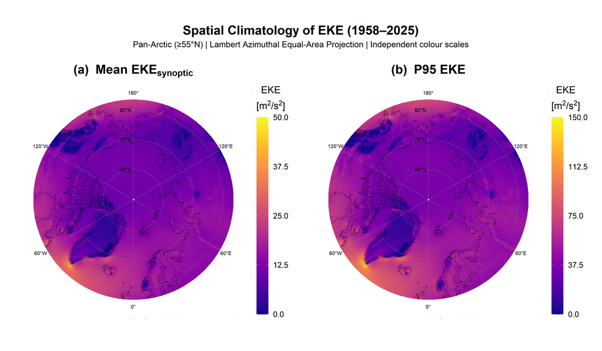

```r
# Helper: shared theme for every panel in this figure
panel_theme <- theme_void(base_size = BASE_SIZE) +
  theme(
    plot.title        = element_text(face = "bold", hjust = 0.5, size = TITLE_SIZE),
    legend.position   = "right",
    legend.key.width  = unit(0.6, "cm"),
    legend.key.height = unit(2.0, "cm"),
    panel.background  = element_rect(fill = "gray95", color = NA),
    plot.margin       = margin(10, 15, 10, 15)
  )

eke_scale_syn <- scale_fill_viridis(
  name     = expression(atop("EKE", "[m"^2*"/s"^2*"]")),
  option   = "C",
  na.value = "transparent",
  limits   = c(0, syn_max),
  breaks   = syn_breaks,
  oob      = scales::squish
)

eke_scale_p95_fig6a <- scale_fill_viridis(
  name     = expression(atop("EKE", "[m"^2*"/s"^2*"]")),
  option   = "C",
  na.value = "transparent",
  limits   = c(0, p95_max),
  breaks   = p95_breaks,
  oob      = scales::squish
)

eke_scale_p90 <- scale_fill_viridis(
  name     = expression(atop("EKE", "[m"^2*"/s"^2*"]")),
  option   = "C",
  na.value = "transparent",
  limits   = c(0, p90_max),
  breaks   = p90_breaks,
  oob      = scales::squish
)

eke_scale_p99 <- scale_fill_viridis(
  name     = expression(atop("EKE", "[m"^2*"/s"^2*"]")),
  option   = "C",
  na.value = "transparent",
  limits   = c(0, p99_max),
  breaks   = p99_breaks,
  oob      = scales::squish
)

# --- Panel (a): Mean EKE ---
p6a_mean <- ggplot() +
  geom_stars(data = clim_polar_masked, aes(fill = eke_synoptic_mean), na.rm = TRUE) +
  eke_scale_syn +
  geom_sf(data = world_polar, fill = NA, color = "black", linewidth = 0.2) +
  geom_sf(data = graticules, color = "gray50", linetype = "dashed", linewidth = 0.25) +
  geom_sf(data = inverse_mask, fill = "white", color = NA) +
  geom_sf_text(data = lat_labels, aes(label = label),
               size = 2.5, color = "black", hjust = 1.2) +
  geom_sf_text(data = lon_labels, aes(label = label),
               size = 2.5, color = "black") +
  coord_sf(xlim = c(-plot_radius, plot_radius),
           ylim = c(-plot_radius, plot_radius), expand = FALSE) +
  labs(title = parse(text = paste0('bold("(a) "~', VAR_LABELS_SHORT[["eke_synoptic_mean"]], ')'))[[1]]) +
  panel_theme

# --- Panel (b): P95 EKE ---
p6a_p95 <- ggplot() +
  geom_stars(data = clim_polar_masked, aes(fill = eke_p95), na.rm = TRUE) +
  eke_scale_p95_fig6a +
  geom_sf(data = world_polar, fill = NA, color = "black", linewidth = 0.2) +
  geom_sf(data = graticules, color = "gray50", linetype = "dashed", linewidth = 0.25) +
  geom_sf(data = inverse_mask, fill = "white", color = NA) +
  geom_sf_text(data = lat_labels, aes(label = label),
               size = 2.5, color = "black", hjust = 1.2) +
  geom_sf_text(data = lon_labels, aes(label = label),
               size = 2.5, color = "black") +
  coord_sf(xlim = c(-plot_radius, plot_radius),
           ylim = c(-plot_radius, plot_radius), expand = FALSE) +
  labs(title = parse(text = paste0('bold("(b) "~', VAR_LABELS_SHORT[["eke_p95"]], ')'))[[1]]) +
  panel_theme

fig6a <- (p6a_mean | p6a_p95) +
  plot_layout() +
  plot_annotation(
    title    = "Spatial Climatology of EKE (1958–2025)",
    subtitle = "Pan-Arctic (≥55°N) | Lambert Azimuthal Equal-Area Projection | Independent colour scales",
    theme = theme(
      plot.title    = element_text(size = TITLE_SIZE, face = "bold", hjust = 0.5),
      plot.subtitle = element_text(size = SUBTITLE_SIZE, hjust = 0.5)
    )
  )

print(fig6a)
```

```r
ggsave(file.path(fig_dir, "Fig06a_EKE_Synoptic_P95_Climatology.png"),
       fig6a, width = 14, height = 7, dpi = 300, bg = "white")
```

```r
# FIGURE 6b: P90 EKE (standalone)
# ==========================================================================
cat("\n--- Generating Figure 6b: Spatial Climatology P90 EKE ---\n")
```

```
--- Generating Figure 6b: Spatial Climatology P90 EKE ---
```

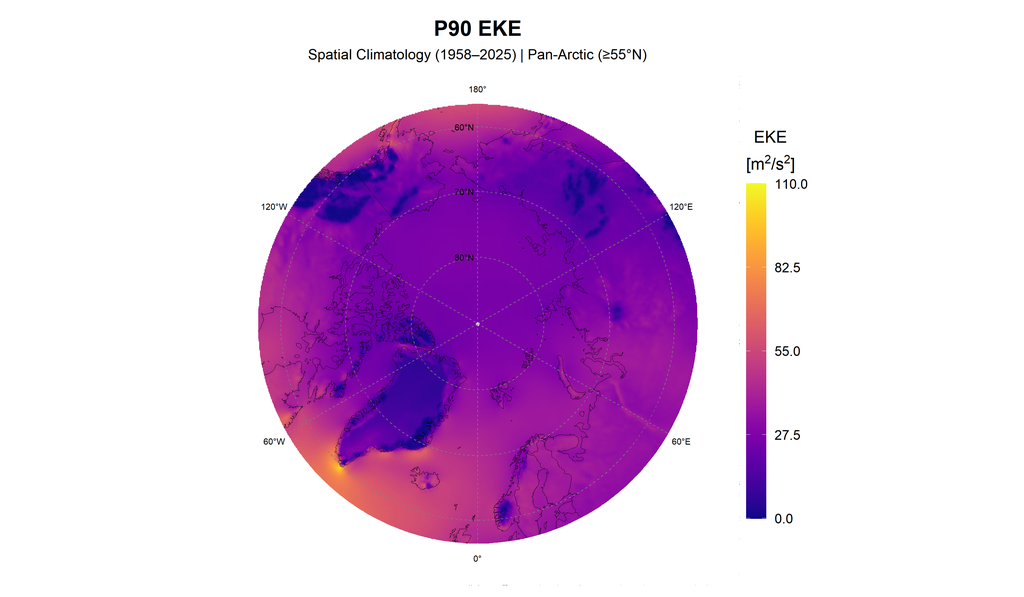

```r
p6b_p90 <- ggplot() +
  geom_stars(data = clim_polar_masked, aes(fill = eke_p90), na.rm = TRUE) +
  eke_scale_p90 +
  geom_sf(data = world_polar, fill = NA, color = "black", linewidth = 0.2) +
  geom_sf(data = graticules, color = "gray50", linetype = "dashed", linewidth = 0.25) +
  geom_sf(data = inverse_mask, fill = "white", color = NA) +
  geom_sf_text(data = lat_labels, aes(label = label),
               size = 2.5, color = "black", hjust = 1.2) +
  geom_sf_text(data = lon_labels, aes(label = label),
               size = 2.5, color = "black") +
  coord_sf(xlim = c(-plot_radius, plot_radius),
           ylim = c(-plot_radius, plot_radius), expand = FALSE) +
  labs(
    title    = parse(text = paste0('bold(', VAR_LABELS_SHORT[["eke_p90"]], ')'))[[1]],
    subtitle = "Spatial Climatology (1958–2025) | Pan-Arctic (≥55°N)"
  ) +
  panel_theme +
  theme(plot.subtitle = element_text(size = SUBTITLE_SIZE, hjust = 0.5))

print(p6b_p90)
```

```r
ggsave(file.path(fig_dir, "Fig06b_EKE_P90_Climatology.png"),
       p6b_p90, width = 8, height = 8, dpi = 300, bg = "white")
```

```r
# FIGURE 6c: P99 EKE (standalone)
# ==========================================================================
cat("\n--- Generating Figure 6c: Spatial Climatology P99 EKE ---\n")
```

```
--- Generating Figure 6c: Spatial Climatology P99 EKE ---
```

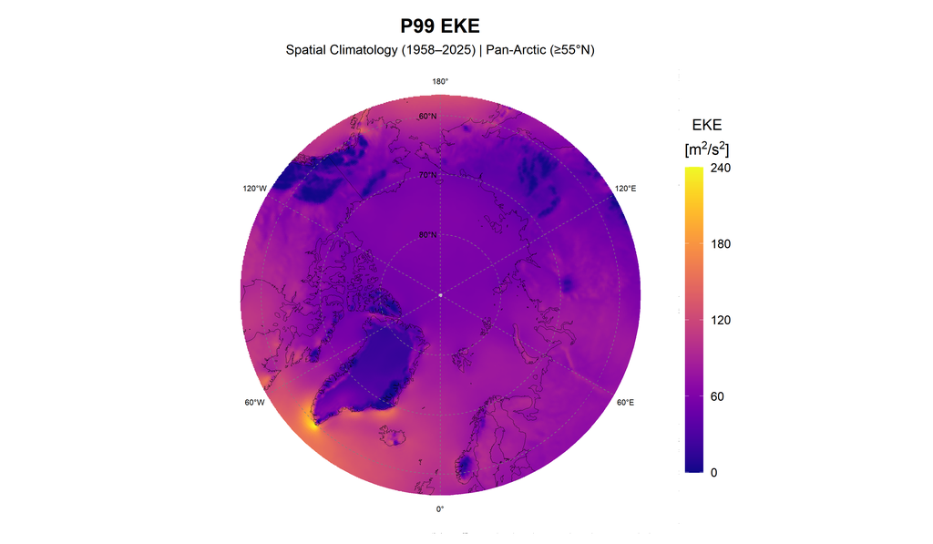

```r
p6c_p99 <- ggplot() +
  geom_stars(data = clim_polar_masked, aes(fill = eke_p99), na.rm = TRUE) +
  eke_scale_p99 +
  geom_sf(data = world_polar, fill = NA, color = "black", linewidth = 0.2) +
  geom_sf(data = graticules, color = "gray50", linetype = "dashed", linewidth = 0.25) +
  geom_sf(data = inverse_mask, fill = "white", color = NA) +
  geom_sf_text(data = lat_labels, aes(label = label),
               size = 2.5, color = "black", hjust = 1.2) +
  geom_sf_text(data = lon_labels, aes(label = label),
               size = 2.5, color = "black") +
  coord_sf(xlim = c(-plot_radius, plot_radius),
           ylim = c(-plot_radius, plot_radius), expand = FALSE) +
  labs(
    title    = parse(text = paste0('bold(', VAR_LABELS_SHORT[["eke_p99"]], ')'))[[1]],
    subtitle = "Spatial Climatology (1958–2025) | Pan-Arctic (≥55°N)"
  ) +
  panel_theme +
  theme(plot.subtitle = element_text(size = SUBTITLE_SIZE, hjust = 0.5))

print(p6c_p99)
```

```r
ggsave(file.path(fig_dir, "Fig06c_EKE_P99_Climatology.png"),
       p6c_p99, width = 8, height = 8, dpi = 300, bg = "white")
```

```r
# FIGURE 6b: P95/MEAN RATIO + EXCEEDANCE FREQUENCY
# ==========================================================================
cat("\n--- Generating Figure 6b: P95/Mean Ratio + Exceedance Frequency ---\n")
```

```
--- Generating Figure 6b: P95/Mean Ratio + Exceedance Frequency ---
```

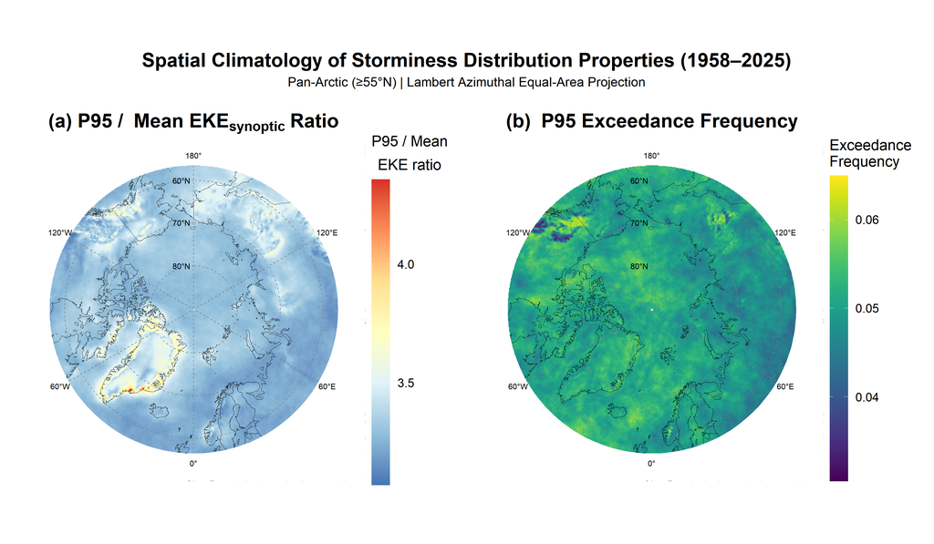

```r
# --- Panel (a): P95/Mean EKE Ratio ---
p6b_ratio <- ggplot() +
  geom_stars(data = clim_polar_masked, aes(fill = p95_mean_ratio), na.rm = TRUE) +
  scale_fill_distiller(
    name      = expression(atop("P95 / Mean", "EKE ratio")),
    palette   = "RdYlBu",
    direction = -1,
    na.value  = "transparent",
    breaks    = scales::pretty_breaks(n = 4)
  ) +
  geom_sf(data = world_polar, fill = NA, color = "black", linewidth = 0.2) +
  geom_sf(data = graticules, color = "gray50", linetype = "dashed", linewidth = 0.25) +
  geom_sf(data = inverse_mask, fill = "white", color = NA) +
  geom_sf_text(data = lat_labels, aes(label = label),
               size = 2.5, color = "black", hjust = 1.2) +
  geom_sf_text(data = lon_labels, aes(label = label),
               size = 2.5, color = "black") +
  coord_sf(xlim = c(-plot_radius, plot_radius),
           ylim = c(-plot_radius, plot_radius), expand = FALSE) +
  labs(title = parse(text = paste0('bold("(a) P95 / "~', VAR_LABELS_SHORT[["eke_synoptic_mean"]], '~"Ratio")'))[[1]]) +
  theme_void(base_size = BASE_SIZE) +
  theme(
    plot.title = element_text(face = "bold", hjust = 0.5, size = TITLE_SIZE),
    legend.position = "right",
    legend.key.width  = unit(0.6, "cm"),
    legend.key.height = unit(2.0, "cm"),
    panel.background = element_rect(fill = "gray95", color = NA),
    plot.margin = margin(10, 15, 10, 15)
  )

# --- Panel (b): P95 Exceedance Frequency ---
p6b_exceed <- ggplot() +
  geom_stars(data = clim_polar_masked, aes(fill = exceed_freq), na.rm = TRUE) +
  scale_fill_viridis(
    name     = "Exceedance\nFrequency",
    option   = "D",
    na.value = "transparent"
  ) +
  geom_sf(data = world_polar, fill = NA, color = "black", linewidth = 0.2) +
  geom_sf(data = graticules, color = "gray50", linetype = "dashed", linewidth = 0.25) +
  geom_sf(data = inverse_mask, fill = "white", color = NA) +
  geom_sf_text(data = lat_labels, aes(label = label),
               size = 2.5, color = "black", hjust = 1.2) +
  geom_sf_text(data = lon_labels, aes(label = label),
               size = 2.5, color = "black") +
  coord_sf(xlim = c(-plot_radius, plot_radius),
           ylim = c(-plot_radius, plot_radius), expand = FALSE) +
  labs(title = parse(text = paste0('bold("(b) "~', VAR_LABELS_SHORT[["exceed_p95_freq"]], ')'))[[1]]) +
  theme_void(base_size = BASE_SIZE) +
  theme(
    plot.title = element_text(face = "bold", hjust = 0.5, size = TITLE_SIZE),
    legend.position = "right",
    legend.key.width  = unit(0.6, "cm"),
    legend.key.height = unit(2.0, "cm"),
    panel.background = element_rect(fill = "gray95", color = NA),
    plot.margin = margin(10, 15, 10, 15)
  )

# --- Combine ---
# No guides = "collect" here because the two panels have DIFFERENT scales.
fig6b <- p6b_ratio + p6b_exceed +
  plot_layout(ncol = 2) +
  plot_annotation(
    title    = "Spatial Climatology of Storminess Distribution Properties (1958–2025)",
    subtitle = "Pan-Arctic (≥55°N) | Lambert Azimuthal Equal-Area Projection",
    theme = theme(
      plot.title    = element_text(size = TITLE_SIZE, face = "bold", hjust = 0.5),
      plot.subtitle = element_text(size = SUBTITLE_SIZE, hjust = 0.5)
    )
  )

print(fig6b)
```

```r
ggsave(file.path(fig_dir, "Fig06b_EKE_Distribution_Climatology.png"),
       fig6b, width = 14, height = 7, dpi = 300, bg = "white")
```

```r
# STANDALONE INDIVIDUAL FIGURES (each variable, own colourbar)
# ==========================================================================
# Each panel is rebuilt with its own independent scale so the colourbar
# reflects that variable's own data range, not the shared Fig06a range.
cat("\n--- Generating standalone individual spatial climatology figures ---\n")
```

```
--- Generating standalone individual spatial climatology figures ---
```

```r
make_standalone <- function(fill_var, scale_obj, label_expr) {
  ggplot() +
    geom_stars(data = clim_polar_masked, aes(fill = .data[[fill_var]]), na.rm = TRUE) +
    scale_obj +
    geom_sf(data = world_polar, fill = NA, color = "black", linewidth = 0.2) +
    geom_sf(data = graticules, color = "gray50", linetype = "dashed", linewidth = 0.25) +
    geom_sf(data = inverse_mask, fill = "white", color = NA) +
    geom_sf_text(data = lat_labels, aes(label = label),
                 size = 2.5, color = "black", hjust = 1.2) +
    geom_sf_text(data = lon_labels, aes(label = label),
                 size = 2.5, color = "black") +
    coord_sf(xlim = c(-plot_radius, plot_radius),
             ylim = c(-plot_radius, plot_radius), expand = FALSE) +
    labs(
      title    = parse(text = paste0("bold(", label_expr, ")"))[[1]],
      subtitle = "Spatial Climatology (1958–2025) | Pan-Arctic (≥55°N)"
    ) +
    panel_theme +
    theme(plot.subtitle = element_text(size = SUBTITLE_SIZE, hjust = 0.5))
}

# EKE_synoptic — own scale
p_solo_syn <- make_standalone(
  "eke_synoptic_mean",
  scale_fill_viridis(name = expression(atop("EKE", "[m"^2*"/s"^2*"]")),
                     option = "C", na.value = "transparent",
                     limits = c(0, syn_max), breaks = syn_breaks,
                     oob = scales::squish),
  VAR_LABELS_SHORT[["eke_synoptic_mean"]]
)
ggsave(file.path(fig_dir, "Fig06_solo_EKE_synoptic.png"),
       p_solo_syn, width = 8, height = 8, dpi = 300, bg = "white")

# P90 — own scale
p_solo_p90 <- make_standalone(
  "eke_p90",
  scale_fill_viridis(name = expression(atop("EKE", "[m"^2*"/s"^2*"]")),
                     option = "C", na.value = "transparent",
                     limits = c(0, p90_max), breaks = p90_breaks,
                     oob = scales::squish),
  VAR_LABELS_SHORT[["eke_p90"]]
)
ggsave(file.path(fig_dir, "Fig06_solo_EKE_P90.png"),
       p_solo_p90, width = 8, height = 8, dpi = 300, bg = "white")

# P95 — own scale
p_solo_p95 <- make_standalone(
  "eke_p95",
  scale_fill_viridis(name = expression(atop("EKE", "[m"^2*"/s"^2*"]")),
                     option = "C", na.value = "transparent",
                     limits = c(0, p95_max), breaks = p95_breaks,
                     oob = scales::squish),
  VAR_LABELS_SHORT[["eke_p95"]]
)
ggsave(file.path(fig_dir, "Fig06_solo_EKE_P95.png"),
       p_solo_p95, width = 8, height = 8, dpi = 300, bg = "white")

# P99 — own scale
p_solo_p99 <- make_standalone(
  "eke_p99",
  scale_fill_viridis(name = expression(atop("EKE", "[m"^2*"/s"^2*"]")),
                     option = "C", na.value = "transparent",
                     limits = c(0, p99_max), breaks = p99_breaks,
                     oob = scales::squish),
  VAR_LABELS_SHORT[["eke_p99"]]
)
ggsave(file.path(fig_dir, "Fig06_solo_EKE_P99.png"),
       p_solo_p99, width = 8, height = 8, dpi = 300, bg = "white")
ggsave(file.path(fig_dir, "Fig06b1_P95MeanRatio_Polar.png"),
       p6b_ratio, width = 8, height = 8, dpi = 300, bg = "white")
ggsave(file.path(fig_dir, "Fig06b2_ExceedFreq_Polar.png"),
       p6b_exceed, width = 8, height = 8, dpi = 300, bg = "white")
```

```r
# FIGURE 6d: SEASONAL SPATIAL CLIMATOLOGY (2×2: DJF, MAM, JJA, SON)
# ==========================================================================
cat("\n--- Generating Figure 6d: Seasonal Spatial Climatology (Mean EKE) ---\n")
```

```
--- Generating Figure 6d: Seasonal Spatial Climatology (Mean EKE) ---
```

```r
# Use Stage 1 climatologies from 68 complete seasons.


seasonal_clim_maps <- prepared$variables$eke_synoptic_mean$seasonal_climatology

# --- 2. Build stars objects for each season (wrap → project → mask) ---
season_panels_clim <- list()

# Shared colour limits across all four seasons
seas_vals <- unlist(lapply(seasonal_clim_maps, function(m) {
  wrapped <- wrap_data(m)
  s <- st_as_stars(list(eke = wrapped),
                   dimensions = st_dimensions(x = lon_wrapped, y = lat_vec)) %>%
    st_set_crs(4326)
  sp <- st_warp(s, crs = arctic_crs)
  sm <- sp[circle_mask]
  as.vector(sm[["eke"]])
}))
seas_max    <- ceiling(max(seas_vals, na.rm = TRUE) / 10) * 10
seas_breaks <- seq(0, seas_max, length.out = 5)

cat(sprintf("  Shared seasonal colour limits: [0, %d]\n", seas_max))
```

```
  Shared seasonal colour limits: [0, 60]
```

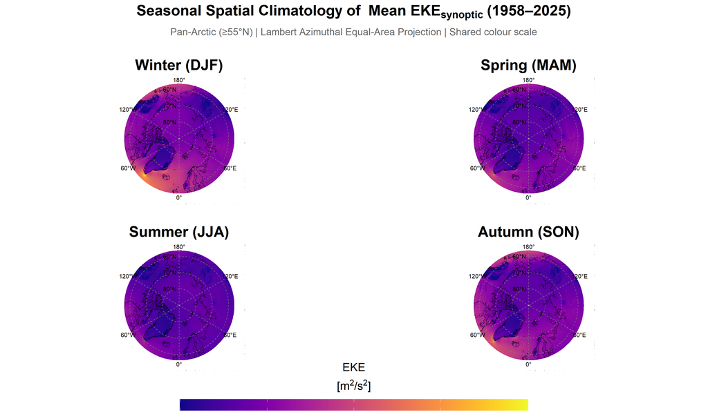

```r
eke_scale_seasonal <- function() {
  scale_fill_viridis(
    name     = expression(atop("EKE", "[m"^2*"/s"^2*"]")),
    option   = "C",
    na.value = "transparent",
    limits   = c(0, seas_max),
    breaks   = seas_breaks,
    oob      = scales::squish
  )
}

for (seas in SEASONS) {
  # Wrap, create stars, project, mask
  mat_w  <- wrap_data(seasonal_clim_maps[[seas]])
  s_star <- st_as_stars(list(eke = mat_w),
                        dimensions = st_dimensions(x = lon_wrapped, y = lat_vec)) %>%
    st_set_crs(4326)
  s_polar  <- st_warp(s_star, crs = arctic_crs)
  s_masked <- s_polar[circle_mask]

  season_panels_clim[[seas]] <- ggplot() +
    geom_stars(data = s_masked, aes(fill = eke), na.rm = TRUE) +
    eke_scale_seasonal() +
    geom_sf(data = world_polar, fill = NA, color = "black", linewidth = 0.2) +
    geom_sf(data = graticules, color = "gray50", linetype = "dashed", linewidth = 0.25) +
    geom_sf(data = inverse_mask, fill = "white", color = NA) +
    geom_sf_text(data = lat_labels, aes(label = label),
                 size = 2.5, color = "black", hjust = 1.2) +
    geom_sf_text(data = lon_labels, aes(label = label),
                 size = 2.5, color = "black") +
    coord_sf(xlim = c(-plot_radius, plot_radius),
             ylim = c(-plot_radius, plot_radius), expand = FALSE) +
    labs(title = SEASON_NAMES[seas]) +
    panel_theme
}

# --- 3. Apply horizontal bottom legend to each panel (S7-safe) ---
legend_style_clim <- theme(
  legend.direction      = "horizontal",
  legend.title.position = "top",
  legend.title          = element_text(size = BASE_SIZE, hjust = 0.5),
  legend.key.width      = unit(3.0, "cm"),
  legend.key.height     = unit(0.5, "cm")
)
legend_guide_clim <- guides(fill = guide_colorbar(title.position = "top",
                                                   title.hjust = 0.5))

for (seas in names(season_panels_clim)) {
  season_panels_clim[[seas]] <- season_panels_clim[[seas]] +
    legend_style_clim + legend_guide_clim
}

# --- 4. Combine 2×2 + guide_area (same pattern as Phase 3 seasonal maps) ---
fig6d <- (season_panels_clim[["DJF"]] + season_panels_clim[["MAM"]] +
            season_panels_clim[["JJA"]] + season_panels_clim[["SON"]] +
            guide_area()) +
  plot_layout(design = "AB\nCD\nEE", guides = "collect",
              heights = c(1, 1, 0.15)) +
  plot_annotation(
    title    = parse(text = 'bold("Seasonal Spatial Climatology of "~"Mean EKE"[synoptic]~"(1958–2025)")')[[1]],
    subtitle = "Pan-Arctic (≥55°N) | Lambert Azimuthal Equal-Area Projection | Shared colour scale",
    theme = theme(
      plot.title    = element_text(face = "bold", size = TITLE_SIZE, hjust = 0.5),
      plot.subtitle = element_text(size = SUBTITLE_SIZE, colour = "grey40",
                                   hjust = 0.5, margin = margin(b = 10))
    )
  )

print(fig6d)
```

```r
ggsave(file.path(fig_dir, "Fig06d_Seasonal_Climatology_EKE.png"),
       fig6d, width = 14, height = 15, dpi = 300, bg = "white")
rm(season_panels_clim, seasonal_clim_maps, seas_vals, fig6d)
gc(verbose = FALSE)
```

```
           used  (Mb) gc trigger  (Mb) max used  (Mb)
Ncells  3410117 182.2    7304534 390.2  7304534 390.2
Vcells 33582238 256.3   60988444 465.4 60988444 465.4
```

```r
# FIGURE 6e: SEASONAL SPATIAL CLIMATOLOGY — P95 EKE (2×2: DJF, MAM, JJA, SON)
# ==========================================================================
cat("\n--- Generating Figure 6e: Seasonal Spatial Climatology (P95 EKE) ---\n")
```

```
--- Generating Figure 6e: Seasonal Spatial Climatology (P95 EKE) ---
```

```r
seasonal_clim_maps_p95 <- prepared$variables$eke_p95$seasonal_climatology

# Shared colour limits across all four seasons
seas_vals_p95 <- unlist(lapply(seasonal_clim_maps_p95, function(m) {
  wrapped <- wrap_data(m)
  s <- st_as_stars(list(eke = wrapped),
                   dimensions = st_dimensions(x = lon_wrapped, y = lat_vec)) %>%
    st_set_crs(4326)
  sp <- st_warp(s, crs = arctic_crs)
  sm <- sp[circle_mask]
  as.vector(sm[["eke"]])
}))
seas_max_p95    <- ceiling(max(seas_vals_p95, na.rm = TRUE) / 10) * 10
seas_breaks_p95 <- seq(0, seas_max_p95, length.out = 5)

cat(sprintf("  Shared seasonal P95 colour limits: [0, %d]\n", seas_max_p95))
```

```
  Shared seasonal P95 colour limits: [0, 200]
```

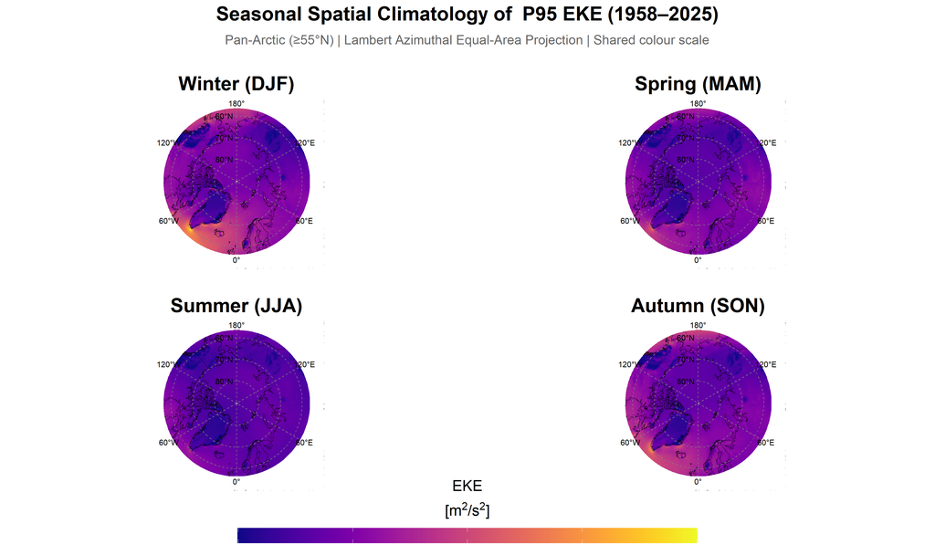

```r
eke_scale_seasonal_p95 <- function() {
  scale_fill_viridis(
    name     = expression(atop("EKE", "[m"^2*"/s"^2*"]")),
    option   = "C",
    na.value = "transparent",
    limits   = c(0, seas_max_p95),
    breaks   = seas_breaks_p95,
    oob      = scales::squish
  )
}

season_panels_clim_p95 <- list()
for (seas in SEASONS) {
  mat_w  <- wrap_data(seasonal_clim_maps_p95[[seas]])
  s_star <- st_as_stars(list(eke = mat_w),
                        dimensions = st_dimensions(x = lon_wrapped, y = lat_vec)) %>%
    st_set_crs(4326)
  s_polar  <- st_warp(s_star, crs = arctic_crs)
  s_masked <- s_polar[circle_mask]

  season_panels_clim_p95[[seas]] <- ggplot() +
    geom_stars(data = s_masked, aes(fill = eke), na.rm = TRUE) +
    eke_scale_seasonal_p95() +
    geom_sf(data = world_polar, fill = NA, color = "black", linewidth = 0.2) +
    geom_sf(data = graticules, color = "gray50", linetype = "dashed", linewidth = 0.25) +
    geom_sf(data = inverse_mask, fill = "white", color = NA) +
    geom_sf_text(data = lat_labels, aes(label = label),
                 size = 2.5, color = "black", hjust = 1.2) +
    geom_sf_text(data = lon_labels, aes(label = label),
                 size = 2.5, color = "black") +
    coord_sf(xlim = c(-plot_radius, plot_radius),
             ylim = c(-plot_radius, plot_radius), expand = FALSE) +
    labs(title = SEASON_NAMES[seas]) +
    panel_theme
}

# Apply horizontal bottom legend to each panel (S7-safe)
for (seas in names(season_panels_clim_p95)) {
  season_panels_clim_p95[[seas]] <- season_panels_clim_p95[[seas]] +
    legend_style_clim + legend_guide_clim
}

# Combine 2×2 + guide_area
fig6e <- (season_panels_clim_p95[["DJF"]] + season_panels_clim_p95[["MAM"]] +
            season_panels_clim_p95[["JJA"]] + season_panels_clim_p95[["SON"]] +
            guide_area()) +
  plot_layout(design = "AB\nCD\nEE", guides = "collect",
              heights = c(1, 1, 0.15)) +
  plot_annotation(
    title    = parse(text = 'bold("Seasonal Spatial Climatology of "~"P95 EKE"~"(1958–2025)")')[[1]],
    subtitle = "Pan-Arctic (≥55°N) | Lambert Azimuthal Equal-Area Projection | Shared colour scale",
    theme = theme(
      plot.title    = element_text(face = "bold", size = TITLE_SIZE, hjust = 0.5),
      plot.subtitle = element_text(size = SUBTITLE_SIZE, colour = "grey40",
                                   hjust = 0.5, margin = margin(b = 10))
    )
  )

print(fig6e)
```

```r
ggsave(file.path(fig_dir, "Fig06e_Seasonal_Climatology_P95_EKE.png"),
       fig6e, width = 14, height = 15, dpi = 300, bg = "white")
rm(season_panels_clim_p95, seasonal_clim_maps_p95, seas_vals_p95, fig6e)
gc(verbose = FALSE)
```

```
           used  (Mb) gc trigger  (Mb) max used  (Mb)
Ncells  3410609 182.2    7304534 390.2  7304534 390.2
Vcells 33583663 256.3   73601988 561.6 61268324 467.5
```

## 2.6 Distributions, metric correlations and period composites

Monthly correlations include a shared seasonal cycle, so they do not prove that anomalies or long-term trends covary. The period composites retain the original bins: 1958–1969 contains 12 years and 2020–2025 contains six. Their labels now match the data, and December 1957 is excluded from these calendar composites. They are descriptive comparisons, not a homogeneity test.

```r
# ============================================================================
```

```r
# PLOT 7: DISTRIBUTION PLOTS (HISTOGRAMS + DENSITY)
# ============================================================================

cat("\n--- Generating Plot 7: Distribution Plots ---\n")
```

```
--- Generating Plot 7: Distribution Plots ---
```

```r
# Prepare data
dist_data <- storm_df %>%
  select(all_of(METRICS)) %>%
  pivot_longer(everything(), names_to = "metric", values_to = "value") %>%
  mutate(metric = factor(metric, levels = METRICS))

p7 <- ggplot(dist_data, aes(x = value, fill = metric)) +
  geom_histogram(aes(y = after_stat(density)), bins = 50, alpha = 0.7, color = "white") +
  geom_density(color = "black", linewidth = 0.8) +
  facet_wrap(~ metric, scales = "free", ncol = 3,
             labeller = as_labeller(VAR_LABELS, default = label_parsed)) +
  scale_fill_manual(values = metric_colors, guide = "none") +
  labs(
    title = "Distribution of Monthly Storminess Metrics",
    subtitle = "Pan-Arctic (≥60°N) | 1958–2025 | n = 816 months",
    x = "Value",
    y = "Density"
  ) +
  theme_bw(base_size = BASE_SIZE) +
  theme(
    plot.title = element_text(face = "bold", size = TITLE_SIZE),
    strip.text = element_text(face = "bold")
  )

ggsave(file.path(fig_dir, "Fig07_Distributions.png"),
       p7, width = 12, height = 8, dpi = 300)

# ============================================================================
```

```r
# PLOT 8: METRIC CORRELATION MATRIX
# ============================================================================

cat("\n--- Generating Plot 8: Correlation Matrix ---\n")
```

```
--- Generating Plot 8: Correlation Matrix ---
```

```r
# Calculate correlation matrix — keep METRICS as row/col names so downstream
# indexing (cat/sprintf below) uses clean variable keys, not display strings.
cor_data <- storm_df %>%
  select(all_of(METRICS))

cor_matrix <- cor(cor_data, use = "pairwise.complete.obs")
rownames(cor_matrix) <- METRICS
colnames(cor_matrix) <- METRICS

# Build plotmath axis labels from VAR_LABELS_SHORT (setup chunk).
# parse() returns an expression object; scale_x/y_discrete(labels=) accepts
# a named vector of expressions to render each level as plotmath.
cor_axis_labels <- setNames(
  parse(text = VAR_LABELS_SHORT[METRICS]),
  METRICS
)

# Melt to long format and keep upper triangle (including diagonal)
cor_long <- as.data.frame(as.table(cor_matrix), stringsAsFactors = FALSE) %>%
  rename(row_var = Var1, col_var = Var2, correlation = Freq) %>%
  mutate(
    row_var = factor(row_var, levels = METRICS),
    col_var = factor(col_var, levels = METRICS)
  ) %>%
  filter(as.integer(row_var) <= as.integer(col_var))

p8 <- ggplot(cor_long, aes(x = col_var, y = fct_rev(row_var), fill = correlation)) +
  geom_tile(color = "white", linewidth = 0.5) +
  geom_text(aes(label = sprintf("%.2f", correlation)), size = 3.5, color = "black") +
  scale_fill_gradient2(
    low = "#B2182B", mid = "white", high = "#2166AC",
    midpoint = 0, limits = c(-1, 1), name = "r"
  ) +
  scale_x_discrete(labels = cor_axis_labels) +
  scale_y_discrete(labels = cor_axis_labels) +
  labs(
    title    = "Correlation Between Storminess Metrics",
    subtitle = "Pan-Arctic (≥60°N) | 1958–2025",
    x = NULL, y = NULL
  ) +
  theme_minimal(base_size = BASE_SIZE) +
  theme(
    axis.text.x   = element_text(angle = 45, hjust = 1, size = 11),
    axis.text.y   = element_text(hjust = 1),
    plot.title    = element_text(face = "bold", hjust = 0.5),
    plot.subtitle = element_text(hjust = 0.5),
    panel.grid    = element_blank()
  )

ggsave(file.path(fig_dir, "Fig08_Correlation_Matrix.png"),
       p8, width = 11, height = 9, dpi = 300)

# Print correlation summary
cat("\n  Correlation matrix:\n")
```

```
  Correlation matrix:
```

```r
print(round(cor_matrix, 3))
```

```
                  eke_synoptic_mean eke_p90 eke_p95 eke_p99 exceed_p95_freq
eke_synoptic_mean             1.000   0.998   0.995   0.981           0.984
eke_p90                       0.998   1.000   0.998   0.983           0.985
eke_p95                       0.995   0.998   1.000   0.992           0.983
eke_p99                       0.981   0.983   0.992   1.000           0.969
exceed_p95_freq               0.984   0.985   0.983   0.969           1.000
```

```r
# ============================================================================
```

```r
# PLOT 9: ANOMALY TIME SERIES (DESEASONALIZED)
# ============================================================================

cat("\n--- Generating Plot 9: Anomaly Time Series ---\n")
```

```
--- Generating Plot 9: Anomaly Time Series ---
```

```r
# Calculate anomalies (remove seasonal cycle)
storm_df_anom <- storm_df %>%
  group_by(month) %>%
  mutate(
    eke_synoptic_mean_anom = eke_synoptic_mean - mean(eke_synoptic_mean, na.rm = TRUE),
    eke_p95_anom = eke_p95 - mean(eke_p95, na.rm = TRUE),
    exceed_freq_anom = exceed_p95_freq - mean(exceed_p95_freq, na.rm = TRUE)
  ) %>%
  ungroup()

# Plot anomalies
p9a <- ggplot(storm_df_anom, aes(x = date, y = eke_synoptic_mean_anom)) +
  geom_hline(yintercept = 0, color = "gray50") +
  geom_line(color = "#0072B2", alpha = 0.5, linewidth = 0.3) +
  geom_smooth(method = "loess", span = 0.1, color = "#D55E00", se = FALSE, linewidth = 0.8) +
  labs(title = parse(text = paste0('bold(', VAR_LABELS_SHORT[["eke_synoptic_mean"]], '~"Anomaly")'))[[1]],
       y = expression("Anomaly [m"^2*"/s"^2*"]"), x = NULL) +
  scale_x_date(date_breaks = "10 years", date_labels = "%Y") +
  theme_bw(base_size = BASE_SIZE) +
  theme(plot.title = element_text(face = "bold", hjust = 0.5))

p9b <- ggplot(storm_df_anom, aes(x = date, y = eke_p95_anom)) +
  geom_hline(yintercept = 0, color = "gray50") +
  geom_line(color = "#009E73", alpha = 0.5, linewidth = 0.3) +
  geom_smooth(method = "loess", span = 0.1, color = "#D55E00", se = FALSE, linewidth = 0.8) +
  labs(title = parse(text = paste0('bold(', VAR_LABELS_SHORT[["eke_p95"]], '~"Anomaly")'))[[1]],
       y = expression("Anomaly [m"^2*"/s"^2*"]"), x = NULL) +
  scale_x_date(date_breaks = "10 years", date_labels = "%Y") +
  theme_bw(base_size = BASE_SIZE) +
  theme(plot.title = element_text(face = "bold", hjust = 0.5))

p9c <- ggplot(storm_df_anom, aes(x = date, y = exceed_freq_anom)) +
  geom_hline(yintercept = 0, color = "gray50") +
  geom_line(color = "#D55E00", alpha = 0.5, linewidth = 0.3) +
  geom_smooth(method = "loess", span = 0.1, color = "black", se = FALSE, linewidth = 0.8) +
  labs(title = parse(text = paste0('bold(', VAR_LABELS_SHORT[["exceed_p95_freq"]], '~"Anomaly")'))[[1]],
       y = "Anomaly [fraction]", x = NULL) +
  scale_x_date(date_breaks = "10 years", date_labels = "%Y") +
  theme_bw(base_size = BASE_SIZE) +
  theme(plot.title = element_text(face = "bold", hjust = 0.5))

p9_combined <- (p9a / p9b / p9c) +
  plot_annotation(
    title = "Deseasonalized Storminess Anomalies",
    subtitle = "Pan-Arctic (≥60°N) | Monthly anomalies from 1958–2025 climatology",
    theme = theme(
      plot.title = element_text(size = TITLE_SIZE, face = "bold", hjust = 0.5),
      plot.subtitle = element_text(size = SUBTITLE_SIZE, hjust = 0.5)
    )
  )

ggsave(file.path(fig_dir, "Fig09_Anomaly_TimeSeries.png"),
       p9_combined, width = 12, height = 10, dpi = 300)
# ============================================================================
```

```r
# PLOT 10: SEASONAL CYCLE BY DECADE (STABILITY CHECK)
# ============================================================================

cat("\n--- Generating Plot 10: Seasonal Cycle Stability ---\n")
```

```
--- Generating Plot 10: Seasonal Cycle Stability ---
```

```r
# Create decade labels
storm_df_decade <- storm_df %>%
  mutate(
    decade = case_when(
      year >= 1958 & year < 1970 ~ "1958-1969",  # 12 calendar years
      year >= 1970 & year < 1980 ~ "1970-1979",
      year >= 1980 & year < 1990 ~ "1980-1989",
      year >= 1990 & year < 2000 ~ "1990-1999",
      year >= 2000 & year < 2010 ~ "2000-2009",
      year >= 2010 & year < 2020 ~ "2010-2019",
      year >= 2020              ~ "2020-2025"
    ),
    decade = factor(decade, levels = c(
      "1958-1969", "1970-1979", "1980-1989", "1990-1999",
      "2000-2009", "2010-2019", "2020-2025"
    ))
  )

# Calculate seasonal cycle by decade
seasonal_by_decade <- storm_df_decade %>%
  group_by(decade, month) %>%
  summarise(
    eke_synoptic_mean_avg = mean(eke_synoptic_mean, na.rm = TRUE),
    eke_synoptic_mean_se = sd(eke_synoptic_mean, na.rm = TRUE) / sqrt(n()),
    .groups = "drop"
  )

# We will use the built-in viridis scale inside the plot.
p10 <- ggplot(seasonal_by_decade, aes(x = month, y = eke_synoptic_mean_avg,
                                      color = decade, group = decade)) +
  geom_line(linewidth = 1) +
  geom_point(size = 2) +
  scale_x_continuous(breaks = 1:12, labels = month.abb) +

  # 'end = 0.9' prevents the lines from becoming too yellow/invisible
  scale_color_viridis_d(option = "plasma", name = "Decade", end = 0.9) +

  labs(
    title = parse(text = paste0('bold("Evolution of the Seasonal Cycle: "~', VAR_LABELS_SHORT[["eke_synoptic_mean"]], ')'))[[1]],
    subtitle = "Pan-Arctic (≥60°N) | Has the seasonal pattern changed over time?",
    x = NULL,
    y = parse(text = VAR_LABELS[["eke_synoptic_mean"]])[[1]]
  ) +
  theme_bw(base_size = BASE_SIZE) +
  theme(
    plot.title = element_text(face = "bold", size = TITLE_SIZE),
    legend.position = "right"
  )

ggsave(file.path(fig_dir, "Fig10_Seasonal_Cycle_ByDecade.png"),
       p10, width = 12, height = 6, dpi = 300)

# Also create for exceedance frequency
seasonal_exceed_decade <- storm_df_decade %>%
  group_by(decade, month) %>%
  summarise(
    exceed_avg = mean(exceed_p95_freq, na.rm = TRUE),
    .groups = "drop"
  )

p10b <- ggplot(seasonal_exceed_decade, aes(x = month, y = exceed_avg,
                                           color = decade, group = decade)) +
  geom_line(linewidth = 1) +
  geom_point(size = 2) +
  geom_hline(yintercept = 0.05, linetype = "dashed", color = "black") +
  scale_x_continuous(breaks = 1:12, labels = month.abb) +

  # --- MODIFICATION: Apply the same scale to the second plot ---
  scale_color_viridis_d(option = "plasma", name = "Decade", end = 0.9) +

  labs(
    title = parse(text = paste0('bold("Evolution of the Seasonal Cycle: "~', VAR_LABELS_SHORT[["exceed_p95_freq"]], ')'))[[1]],
    subtitle = "Pan-Arctic (≥60°N) | Dashed line = 5% reference frequency",
    x = NULL,
    y = "Exceedance Frequency"
  ) +
  theme_bw(base_size = BASE_SIZE) +
  theme(
    plot.title = element_text(face = "bold", size = TITLE_SIZE),
    legend.position = "right"
  )

ggsave(file.path(fig_dir, "Fig10b_Seasonal_Exceedance_ByDecade.png"),
       p10b, width = 12, height = 6, dpi = 300)

# ============================================================================
```

```r
raw_correlation <- cor(diagnostic_df[METRIC_NAMES])
anomaly_correlation <- cor(as.data.frame(lapply(METRIC_NAMES,
  function(v) deseasonalize(diagnostic_df,v))))
dimnames(anomaly_correlation) <- dimnames(raw_correlation)
write.csv(raw_correlation,file.path(OUTPUT_DATA_DIR,"Metric_Correlations_Raw.csv"))
write.csv(anomaly_correlation,file.path(OUTPUT_DATA_DIR,"Metric_Correlations_Anomalies.csv"))
```

# 3. Describe the energy partition

These are descriptive comparisons of existing monthly products. Budget EKE uses deviations from each month’s mean and satisfies TKE = MKE + EKE. Synoptic EKE uses bandpass-filtered winds. Their ratio is not an exact partition into complementary frequency bands, and correlation does not establish identical trends or an energy-transfer mechanism.

```r
fig_dir <- FIG_PHASE2
```

## 3.1 Energy partition through time

```r
# ============================================================================
# 2.1  ENERGY PARTITIONING
# ============================================================================
# Key question: how is TKE split between mean flow (MKE) and transient
# eddies (EKE_budget), and is this split stable over 68 years?
#
# A stacked area chart shows three things simultaneously:
#   1. Absolute TKE level (~46 m²/s²)
#   2. The approximate 80/20 EKE/MKE split
#   3. The temporal stability of the partitioning
# ============================================================================

cat("--- 2.1 Energy Partitioning Climatology ---\n\n")
```

```
--- 2.1 Energy Partitioning Climatology ---
```

```r
# Report key values
cat(sprintf("  Climatological eddy fraction (f_EKE):  %.1f%%\n",
            mean(storm_df$eke_fraction) * 100))
```

```
  Climatological eddy fraction (f_EKE):  80.2%
```

```r
cat(sprintf("  Climatological MKE/EKE ratio:          %.3f\n",
            mean(storm_df$mke_eke_ratio)))
```

```
  Climatological MKE/EKE ratio:          0.252
```

```r
cat(sprintf("  Range of annual f_EKE:                 %.1f%% – %.1f%%\n",
            min(energy_annual$eke_fraction) * 100,
            max(energy_annual$eke_fraction) * 100))
```

```
  Range of annual f_EKE:                 77.5% – 83.5%
```

```r
# --- Figure 2.1: Stacked Area ---
energy_stack <- energy_annual %>%
  select(year, mke, eke_budget) %>%
  pivot_longer(-year, names_to = "component", values_to = "value") %>%
  mutate(
    # Keep internal keys as factor levels so ENERGY_COLORS maps directly
    component = factor(component, levels = c("eke_budget", "mke"))
  )

# Plotmath legend labels: variable name with subscript + descriptive context
energy_stack_labels <- c(
  "eke_budget" = "EKE[budget]~(Transient~Eddies)",
  "mke"        = "MKE~(Mean~Flow)"
)

p2_1 <- ggplot(energy_stack, aes(x = year, y = value, fill = component)) +
  geom_area(alpha = 0.8) +
  scale_fill_manual(
    values = ENERGY_COLORS[c("eke_budget", "mke")],
    labels = function(x) parse(text = energy_stack_labels[x]),
    name   = NULL
  ) +
  labs(
    title    = "Partitioning of Total Kinetic Energy",
    subtitle = "Pan-Arctic (≥60°N) | Annual means | TKE = MKE + EKE",
    x = NULL,
    y = expression("Kinetic Energy [m"^2*"/s"^2*"]")
  ) +
  theme_bw(base_size = BASE_SIZE) +
  theme(
    plot.title    = element_text(face = "bold", size = TITLE_SIZE),
    legend.position = "bottom"
  )

ggsave(file.path(fig_dir, "Fig2.1_Energy_Budget_Partitioning.png"),
       p2_1, width = 10, height = 6, dpi = 300)
```

## 3.2 Calendar-month energy cycle

```r
# ============================================================================
# 2.2  SEASONAL CYCLE OF ENERGY COMPONENTS
# ============================================================================
# Key question: how does the energy budget vary by month?
#
# This reveals:
#   - TKE and EKE peak in winter (DJF), trough in summer (JJA)
#   - MKE has a much flatter seasonal cycle
#   - Winter EKE is roughly 1.5–2× summer EKE
#   - MKE seasonal amplitude is much smaller than EKE's
# ============================================================================

cat("--- 2.2 Seasonal Cycle of Energy Components ---\n\n")
```

```
--- 2.2 Seasonal Cycle of Energy Components ---
```

```r
energy_seasonal <- storm_df %>%
  group_by(month) %>%
  summarise(
    tke_mean        = mean(tke),
    mke_mean        = mean(mke),
    eke_budget_mean = mean(eke_budget),   # budget EKE (all sub-monthly variance, eq. 2.9)
    .groups         = "drop"
  )

# Report winter/summer contrast
winter_eke <- mean(energy_seasonal$eke_budget_mean[energy_seasonal$month %in% c(12, 1, 2)])
summer_eke <- mean(energy_seasonal$eke_budget_mean[energy_seasonal$month %in% c(6, 7, 8)])
winter_mke <- mean(energy_seasonal$mke_mean[energy_seasonal$month %in% c(12, 1, 2)])
summer_mke <- mean(energy_seasonal$mke_mean[energy_seasonal$month %in% c(6, 7, 8)])

cat(sprintf("  EKE_budget: winter = %.1f, summer = %.1f m²/s² (ratio: %.2f)\n",
            winter_eke, summer_eke, winter_eke / summer_eke))
```

```
  EKE_budget: winter = 46.3, summer = 28.7 m²/s² (ratio: 1.61)
```

```r
cat(sprintf("  MKE:        winter = %.1f, summer = %.1f m²/s² (ratio: %.2f)\n",
            winter_mke, summer_mke, winter_mke / summer_mke))
```

```
  MKE:        winter = 13.5, summer = 6.2 m²/s² (ratio: 2.18)
```

```r
# Long format for plotting
seasonal_long <- energy_seasonal %>%
  select(month, tke_mean, mke_mean, eke_budget_mean) %>%
  pivot_longer(-month, names_to = "component", values_to = "value") %>%
  mutate(
    # Use ENERGY_VARS keys as factor levels so ENERGY_COLORS maps directly
    component = factor(component,
                       levels = c("tke_mean", "mke_mean", "eke_budget_mean"),
                       labels = c("tke", "mke", "eke_budget"))
  )

p2_2 <- ggplot(seasonal_long, aes(x = month, y = value, color = component)) +
  geom_line(linewidth = 1.2) +
  geom_point(size = 3) +
  scale_x_continuous(breaks = 1:12, labels = month.abb) +
  scale_color_manual(
    values = ENERGY_COLORS,
    labels = function(x) parse(text = VAR_LABELS_SHORT[x]),
    name   = "Component"
  ) +
  labs(
    title    = "Climatological Seasonal Cycle of Energy Components",
    subtitle = "Pan-Arctic (≥60°N) | 1958–2025 mean",
    x = NULL,
    y = expression("Kinetic Energy [m"^2*"/s"^2*"]")
  ) +
  theme_bw(base_size = BASE_SIZE) +
  theme(
    plot.title    = element_text(face = "bold", size = TITLE_SIZE),
    legend.position = "bottom"
  )

ggsave(file.path(fig_dir, "Fig2.2_Energy_Seasonal_Cycle.png"),
       p2_2, width = 10, height = 6, dpi = 300)
```

## 3.3 Compare the two EKE definitions

```r
cat("--- 2.3 EKE Definition Comparison ---\n\n")
```

```
--- 2.3 EKE Definition Comparison ---
```

```r
# Compute correlation
eke_cor <- cor(storm_df$eke_budget, storm_df$eke_synoptic_mean, use = "complete.obs")
cat(sprintf("  Pearson r (monthly): %.3f\n", eke_cor))
```

```
  Pearson r (monthly): 0.885
```

```r
# Compute synoptic/budget ratio
storm_df <- storm_df %>%
  mutate(f_synoptic = eke_synoptic_mean / eke_budget)

cat(sprintf("  Mean synoptic/budget ratio (f_synoptic): %.3f (%.1f%%)\n",
            mean(storm_df$f_synoptic, na.rm = TRUE),
            mean(storm_df$f_synoptic, na.rm = TRUE) * 100))
```

```
  Mean synoptic/budget ratio (f_synoptic): 0.328 (32.8%)
```

```r
cat(sprintf("  Range: %.3f – %.3f\n",
            min(storm_df$f_synoptic, na.rm = TRUE),
            max(storm_df$f_synoptic, na.rm = TRUE)))
```

```
  Range: 0.246 – 0.451
```

```r
# Panel (a): Scatter
p_scatter <- ggplot(storm_df, aes(x = eke_budget, y = eke_synoptic_mean)) +
  geom_point(alpha = 0.3, size = 1) +
  geom_smooth(method = "lm", se = FALSE, color = "#E41A1C", linewidth = 1) +
  geom_abline(intercept = 0, slope = 1, linetype = "dashed", color = "gray50") +
  annotate("text",
           x = min(storm_df$eke_budget, na.rm = TRUE) * 1.1,
           y = max(storm_df$eke_synoptic_mean, na.rm = TRUE) * 0.95,
           label = sprintf("r = %.3f", eke_cor),
           hjust = 0, size = 4, fontface = "bold") +
  labs(
    title = parse(text = paste0('bold("(a) "~EKE[budget]~"vs"~EKE[synoptic])'))[[1]],
    x = expression("EKE"["budget"]*" (all sub-monthly variance) [m"^2*"/s"^2*"]"),
    y = expression("EKE"["synoptic"]*" (1.2–6 day bandpass) [m"^2*"/s"^2*"]")
  ) +
  theme_bw(base_size = BASE_SIZE) +
  theme(plot.title = element_text(face = "bold", size = TITLE_SIZE))

# Panel (b): Annual time series
comparison_annual <- energy_annual %>%
  select(year, eke_budget, eke_synoptic_mean) %>%
  pivot_longer(-year, names_to = "type", values_to = "value") %>%
  mutate(
    type = factor(type,
                  levels = c("eke_budget", "eke_synoptic_mean"),
                  labels = c("EKE (budget, all sub-monthly)",
                             "EKE (synoptic, 1.2–6 day)"))
  )

p_ts <- ggplot(comparison_annual, aes(x = year, y = value, color = type)) +
  geom_line(linewidth = 0.8) +
  geom_point(size = 1.5, alpha = 0.7) +
  scale_color_manual(values = c("#7570B3", "#1B9E77"), name = NULL) +
  labs(
    title = "(b) Annual Mean Comparison",
    x = NULL,
    y = expression("EKE [m"^2*"/s"^2*"]")
  ) +
  theme_bw(base_size = BASE_SIZE) +
  theme(
    plot.title    = element_text(face = "bold", size = TITLE_SIZE),
    legend.position = "bottom"
  )

# Combine
p2_3 <- p_scatter + p_ts +
  plot_layout(ncol = 2, widths = c(1, 1.2)) +
  plot_annotation(
    title    = "Comparison of EKE Definitions",
    subtitle = "Budget EKE: within-month variance | Synoptic EKE: 1.2–6 day filter",
    theme = theme(
      plot.title    = element_text(size = TITLE_SIZE, face = "bold", hjust = 0.5),
      plot.subtitle = element_text(size = SUBTITLE_SIZE, hjust = 0.5)
    )
  )

ggsave(file.path(fig_dir, "Fig2.3_EKE_Comparison.png"),
       p2_3, width = 14, height = 6, dpi = 300)
```

```r
energy_comparison <- tibble(
  statistic=c("raw monthly Pearson r","anomaly Pearson r","mean synoptic/budget ratio"),
  value=c(cor(diagnostic_df$eke_budget,diagnostic_df$eke_synoptic_mean),
    cor(deseasonalize(diagnostic_df,"eke_budget"),deseasonalize(diagnostic_df,"eke_synoptic_mean")),
    mean(diagnostic_df$eke_synoptic_mean/diagnostic_df$eke_budget)))
write_csv(energy_comparison,file.path(OUTPUT_DATA_DIR,"EKE_Definition_Comparison.csv"))
storm_df <- storm_df_with_buffer  # restore Dec 1957 for any subsequent seasonal work
```

# 4. Estimate annual and seasonal Pan-Arctic trends

## 4.1 Calculate estimates and matching intervals

There are eight annual series and 32 seasonal series. Within this code, the Zhang slope is the Sen-based slope returned by the iterative Zhang procedure; it is not labelled as the unmodified median of all raw-data pairwise slopes. The significance column uses the **unrounded nominal PWMK p-value**. Calculations and CSVs retain full precision; rounding is only for display. `pct_change` is fitted change over 67 years divided by that series’ mean, expressed as a percentage. For exceedance frequency, `exceed_pp_dec` also reports percentage points per decade.

Each result is cached separately against its series, settings, seed, R version and statistical package versions. Rerunning after an interruption reuses completed compatible calculations. A change in N_BOOT or the input values invalidates the affected cache. Old result tables, if present, are joined only for a previous-versus-corrected comparison; they never supply current estimates.

These tests do not attribute changes to sea ice or other causes. Seasonal results are nominal unless a family correction is explicitly applied; five correlated metrics are not five independent confirmations. Significance in one season and nonsignificance in another is not a test of their difference.

```r
# A cache is tied to actual series values, settings, and package versions.
# Old confidence intervals are never reused because their estimator differed.
trend_row <- function(x, years, variable, period, seed) {
  signature <- object_hash(list(schema = "zhang-residual-mbb-v1", framework = FRAMEWORK_VERSION, x = x, years = years,
    N_BOOT = N_BOOT, alpha = ALPHA, fallback = B_FALLBACK, seed = seed,
    R = as.character(getRversion()),
    packages = vapply(c("zyp", "blocklength", "boot"),
                      function(p) as.character(packageVersion(p)), character(1))))
  path <- file.path(TREND_CACHE_DIR, paste0(period, "__", variable, ".rds"))
  old <- if (file.exists(path)) readRDS(path) else NULL
  if (!FORCE_TREND_RECOMPUTE && !is.null(old) && identical(old$signature, signature)) {
    fit <- old$fit
    cat("Reusing:", period, variable, "\n")
  } else {
    cat("Calculating:", period, variable, "with", N_BOOT, "bootstrap replicates\n")
    flush.console()
    fit <- fit_with_mbb(x, years, seed)
    write_rds(list(signature = signature, fit = fit), path)
  }
  average <- mean(x)
  total_change <- fit$beta * diff(range(years))
  tibble(period = period, variable = variable,
    label = unname(VAR_LABELS_PLAIN[variable]),
    group = ifelse(variable %in% METRIC_NAMES, "Storminess", "Energy"),
    n = length(x), mean_val = average, slope_dec = fit$beta*DECADES,
    ci_lower = fit$ci[1]*DECADES, ci_upper = fit$ci[2]*DECADES,
    intercept = fit$intercept, tau = unname(fit$mk["tau"]),
    p_value = unname(fit$mk["sig"]), ar1_removed = unname(fit$mk["autocor"]),
    nruns = unname(fit$mk["nruns"]), significant = unname(fit$mk["sig"]) < ALPHA,
    pct_change = if (average != 0) 100*total_change/average else NA_real_,
    total_change = total_change,
    exceed_pp_dec = if (variable == "exceed_p95_freq") fit$beta*DECADES*100 else NA_real_,
    b_length = fit$block$b, block_fallback = fit$block$fallback,
    block_reason = fit$block$reason, residual_rho1 = fit$residual_rho1,
    bootstrap_seed = seed, bootstrap_R = N_BOOT)
}
results_annual <- bind_rows(lapply(seq_along(ALL_VARS), function(i) {
  v <- ALL_VARS[i]
  trend_row(annual_df[[v]], annual_df$year, v, "Annual", BOOT_SEED+i)
}))
```

```
Reusing: Annual eke_synoptic_mean
Reusing: Annual eke_p90
Reusing: Annual eke_p95
Reusing: Annual eke_p99
Reusing: Annual exceed_p95_freq
Reusing: Annual tke
Reusing: Annual mke
Reusing: Annual eke_budget
```

```r
write_csv(results_annual, file.path(OUTPUT_DATA_DIR, "Annual_Trends_FullPrecision.csv"))
print(knitr::kable(results_annual %>% select(label, slope_dec, ci_lower, ci_upper,
                                           p_value, pct_change, b_length), digits = 5))
```

```
|label                | slope_dec| ci_lower| ci_upper| p_value| pct_change| b_length|
|:--------------------|---------:|--------:|--------:|-------:|----------:|--------:|
|Mean EKE_synoptic    |   0.02498| -0.05238|  0.10201| 0.52311|    1.36388|        2|
|P90 EKE              |   0.06303| -0.12151|  0.23976| 0.49533|    1.43299|        2|
|P95 EKE              |   0.06063| -0.17264|  0.30308| 0.55166|    0.99709|        2|
|P99 EKE              |   0.06680| -0.32317|  0.48307| 0.81180|    0.67422|        2|
|P95 Exceedance Freq. |   0.00026| -0.00038|  0.00091| 0.53018|    3.43976|        2|
|TKE                  |   0.16024| -0.04997|  0.37994| 0.30386|    2.28795|        2|
|MKE                  |   0.01315| -0.10871|  0.13713| 0.87956|    0.92157|        2|
|EKE_budget           |   0.11210| -0.02730|  0.25472| 0.18670|    2.00996|        2|
```

```r
results_seasonal <- bind_rows(lapply(seq_along(SEASONS), function(j) {
  seas <- SEASONS[j]
  d <- seasonal_df %>% filter(season == seas)
  bind_rows(lapply(seq_along(ALL_VARS), function(i) {
    v <- ALL_VARS[i]
    trend_row(d[[v]], d$season_year, v, seas, BOOT_SEED+j*100L+i)
  }))
})) %>% mutate(season = factor(period, levels = SEASONS))
```

```
Reusing: DJF eke_synoptic_mean
Reusing: DJF eke_p90
Reusing: DJF eke_p95
Reusing: DJF eke_p99
Reusing: DJF exceed_p95_freq
Reusing: DJF tke
Reusing: DJF mke
Reusing: DJF eke_budget
Reusing: MAM eke_synoptic_mean
Reusing: MAM eke_p90
Reusing: MAM eke_p95
Reusing: MAM eke_p99
Reusing: MAM exceed_p95_freq
Reusing: MAM tke
Reusing: MAM mke
Reusing: MAM eke_budget
Reusing: JJA eke_synoptic_mean
Reusing: JJA eke_p90
Reusing: JJA eke_p95
Reusing: JJA eke_p99
Reusing: JJA exceed_p95_freq
Reusing: JJA tke
Reusing: JJA mke
Reusing: JJA eke_budget
Reusing: SON eke_synoptic_mean
Reusing: SON eke_p90
Reusing: SON eke_p95
Reusing: SON eke_p99
Reusing: SON exceed_p95_freq
Reusing: SON tke
Reusing: SON mke
Reusing: SON eke_budget
```

```r
write_csv(results_seasonal, file.path(OUTPUT_DATA_DIR, "Seasonal_Trends_FullPrecision.csv"))
print(knitr::kable(results_seasonal %>% select(season, label, slope_dec, ci_lower,
  ci_upper, p_value, pct_change, b_length), digits = 5))
```

```
|season |label                | slope_dec| ci_lower| ci_upper| p_value| pct_change| b_length|
|:------|:--------------------|---------:|--------:|--------:|-------:|----------:|--------:|
|DJF    |Mean EKE_synoptic    |  -0.05657| -0.21244|  0.09390| 0.44276|   -2.52860|        1|
|DJF    |P90 EKE              |  -0.14977| -0.52953|  0.21230| 0.47485|   -2.78620|        1|
|DJF    |P95 EKE              |  -0.23196| -0.79240|  0.27435| 0.39998|   -3.12309|        1|
|DJF    |P99 EKE              |  -0.44969| -1.28697|  0.34929| 0.35979|   -3.72297|        1|
|DJF    |P95 Exceedance Freq. |  -0.00052| -0.00190|  0.00090| 0.45544|   -4.88362|        1|
|DJF    |TKE                  |  -0.07114| -0.45895|  0.30394| 0.67582|   -0.79816|        1|
|DJF    |MKE                  |  -0.17960| -0.46228|  0.10385| 0.26034|   -8.93430|        1|
|DJF    |EKE_budget           |   0.04934| -0.23647|  0.36208| 0.75480|    0.71475|        1|
|MAM    |Mean EKE_synoptic    |   0.14832|  0.04999|  0.24987| 0.02055|    8.60345|        2|
|MAM    |P90 EKE              |   0.36308|  0.12667|  0.60889| 0.01580|    8.74023|        1|
|MAM    |P95 EKE              |   0.45516|  0.11539|  0.78933| 0.02651|    7.91138|        1|
|MAM    |P99 EKE              |   0.66576|  0.11847|  1.27344| 0.06266|    7.07992|        2|
|MAM    |P95 Exceedance Freq. |   0.00117|  0.00034|  0.00201| 0.02176|   17.57138|        1|
|MAM    |TKE                  |   0.38230|  0.06397|  0.70407| 0.04188|    5.76302|        1|
|MAM    |MKE                  |   0.17843| -0.00917|  0.37713| 0.07795|   13.33929|        1|
|MAM    |EKE_budget           |   0.19394| -0.03097|  0.43404| 0.15002|    3.66201|        2|
|JJA    |Mean EKE_synoptic    |   0.02794| -0.03678|  0.09224| 0.42411|    2.03238|        2|
|JJA    |P90 EKE              |   0.08603| -0.07061|  0.24540| 0.41194|    2.60747|        2|
|JJA    |P95 EKE              |   0.09171| -0.09607|  0.29611| 0.34879|    2.00871|        2|
|JJA    |P99 EKE              |   0.19958| -0.11592|  0.50249| 0.28734|    2.68347|        2|
|JJA    |P95 Exceedance Freq. |   0.00040| -0.00005|  0.00084| 0.20965|    9.40622|        2|
|JJA    |TKE                  |   0.17683| -0.01040|  0.37556| 0.11161|    3.39833|        1|
|JJA    |MKE                  |   0.13564|  0.01340|  0.25848| 0.06943|   14.72769|        3|
|JJA    |EKE_budget           |   0.05444| -0.08442|  0.18470| 0.54445|    1.27113|        1|
|SON    |Mean EKE_synoptic    |   0.00171| -0.09771|  0.10512| 0.97888|    0.08588|        1|
|SON    |P90 EKE              |   0.03659| -0.22649|  0.28300| 0.77012|    0.76765|        1|
|SON    |P95 EKE              |  -0.00383| -0.34148|  0.34039| 0.97888|   -0.05820|        1|
|SON    |P99 EKE              |  -0.02006| -0.57738|  0.53811| 0.97888|   -0.18720|        1|
|SON    |P95 Exceedance Freq. |   0.00029| -0.00072|  0.00126| 0.62623|    3.36741|        2|
|SON    |TKE                  |   0.02207| -0.24338|  0.29214| 0.86966|    0.30393|        1|
|SON    |MKE                  |  -0.03955| -0.21343|  0.13653| 0.60763|   -2.75079|        1|
|SON    |EKE_budget           |   0.14667| -0.04597|  0.33534| 0.19467|    2.51860|        1|
```

```r
# Export any disagreement between two different inferential procedures rather
# than silently treating a bootstrap CI as the inverse of the PWMK test.
ci_test_comparison <- bind_rows(results_annual, results_seasonal) %>%
  mutate(ci_excludes_zero = ci_lower > 0 | ci_upper < 0,
         ci_pwmk_disagree = ci_excludes_zero != significant)
write_csv(ci_test_comparison, file.path(OUTPUT_DATA_DIR, "CI_and_PWMK_Comparison.csv"))

# Compare to old tables only for audit; old values never enter calculations.
compare_old_results <- function(path, object, new, keys) {
  if (!file.exists(path)) return(invisible(NULL))
  e <- new.env(parent = emptyenv())
  load(path, envir = e)
  if (!exists(object, envir = e, inherits = FALSE)) return(invisible(NULL))
  old <- get(object, envir = e)
  cols <- c(keys, "slope_dec", "p_value", "ci_lower", "ci_upper", "pct_change")
  if (!all(cols %in% names(old))) return(invisible(NULL))
  comparison <- full_join(select(new, all_of(cols)), select(old, all_of(cols)),
                          by = keys, suffix = c("_corrected", "_previous"))
  write_csv(comparison, file.path(OUTPUT_DATA_DIR, paste0(object, "_Previous_vs_Corrected.csv")))
}
compare_old_results(file.path(LEGACY_DATA_DIR,"Phase3_1_Annual_Results.RData"),
                    "results_annual", results_annual, "variable")
compare_old_results(file.path(LEGACY_DATA_DIR,"Phase3_2_Seasonal_Results.RData"),
                    "results_seasonal", results_seasonal, c("season","variable"))

# Compatibility exports use the original object/file names in the NEW folder.
save(results_annual, annual_df,
     file=file.path(OUTPUT_DATA_DIR,"Phase3_1_Annual_Results.RData"))
save(results_seasonal, seasonal_df,
     file=file.path(OUTPUT_DATA_DIR,"Phase3_2_Seasonal_Results.RData"))
```

## 4.2 Trend figures

Lines use the same slope and median intercept as the residual model. Forest plots separate energy units from exceedance fractions; seasonal forest panels compare four seasons within each variable. Colours identify nominal PWMK significance and are independent of the bootstrap intervals. P-values are included in labels rather than placed beyond the axis where they can be clipped.

```r
mid_year <- mean(annual_df$year)

slope_lines <- results_annual %>%
  mutate(
    slope_yr  = slope_dec / DECADES,
    intercept = intercept,
    label_fig = factor(unname(VAR_LABELS[variable]),
                       levels = unname(VAR_LABELS[ALL_VARS]))
  )

annual_long <- annual_df %>%
  pivot_longer(all_of(ALL_VARS),
               names_to  = "variable",
               values_to = "value") %>%
  mutate(
    label_fig = factor(unname(VAR_LABELS[variable]),
                       levels = unname(VAR_LABELS[ALL_VARS])),
    group     = ifelse(variable %in% METRIC_NAMES,
                       "Storminess metrics", "Energy components")
  )

# ── Figure 3.1: Annual time series ──────────────────────────────────────

p_annual <- ggplot(annual_long, aes(x = year, y = value)) +
  geom_line(aes(colour = variable),
            linewidth = 0.6, alpha = 0.8) +
  geom_point(aes(colour = variable),
             size = 0.9, alpha = 0.5) +
  geom_smooth(method = "loess", span = 0.4, se = FALSE,
              colour = "grey40", linewidth = 0.7, linetype = "dashed") +
  geom_abline(
    data      = slope_lines,
    aes(intercept = intercept, slope = slope_yr,
        linetype  = significant),
    colour    = "#D73027",
    linewidth = 0.9
  ) +
  scale_colour_manual(values = ALL_COLORS, guide = "none") +
  scale_linetype_manual(
    values = c("FALSE" = "dotted", "TRUE" = "solid"),
    labels = c("FALSE" = glue("Not significant (\u03b1 = {ALPHA})"),
               "TRUE"  = glue("Significant (\u03b1 = {ALPHA})")),
    name   = "Zhang slope"
  ) +
  facet_wrap(~ label_fig, ncol = 2, scales = "free_y", labeller = label_parsed) +
  scale_x_continuous(breaks = seq(1960, 2020, 10)) +
  labs(
    title    = "Pan-Arctic Storminess and Energy: Annual Trends (1958\u20132025)",
    subtitle = glue(
      "Pre-Whitened Mann\u2013Kendall | Zhang slope (red) | ",
      "LOESS smoother (grey dashed) | N = {nrow(annual_df)} years"
    ),
    x = NULL,
    y = "Annual mean value"
  ) +
  theme_bw(base_size = BASE_SIZE) +
  theme(
    plot.title       = element_text(face = "bold", size = TITLE_SIZE),
    plot.subtitle    = element_text(size = SUBTITLE_SIZE, colour = "grey40"),
    legend.position  = "bottom",
    strip.text = element_text(face = "bold"),
    panel.grid.minor = element_blank()
  )

ggsave(file.path(FIG_PHASE3, "Fig3.1_Annual_Trends.png"),
       p_annual, width = 12, height = 14, dpi = 300)
```

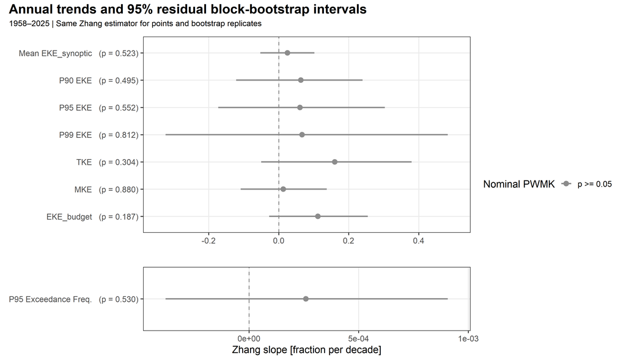

```r
# Label p-values beside the VARIABLE instead of beyond the CI endpoint.
# This prevents clipping and separates unlike units into their own axes.
annual_forest_panel <- function(d, units) {
  d <- d %>% mutate(row_label = paste0(label,"   (p ",ifelse(p_value<0.001,"< 0.001",paste0("= ",formatC(p_value,digits=3,format="f"))),")"),
                    row_label = factor(row_label,levels=rev(row_label)))
  ggplot(d,aes(x=slope_dec,y=row_label,colour=significant)) +
    geom_vline(xintercept=0,linetype="dashed",colour="grey55") +
    geom_segment(aes(x=ci_lower,xend=ci_upper,yend=row_label),linewidth=0.9) +
    geom_point(size=3) +
    scale_colour_manual(values=c("FALSE"="grey55","TRUE"="#D73027"),
                        name="Nominal PWMK",labels=c("FALSE"=paste("p >=",ALPHA),"TRUE"=paste("p <",ALPHA))) +
    scale_x_continuous(expand=expansion(mult=c(0.08,0.08))) +
    labs(x=units,y=NULL) + theme_bw(base_size=BASE_SIZE) +
    theme(legend.position="bottom",panel.grid.minor=element_blank())
}
energy_forest <- annual_forest_panel(
  filter(results_annual,variable!="exceed_p95_freq"),"Zhang slope [m² s⁻² per decade]")
frequency_forest <- annual_forest_panel(
  filter(results_annual,variable=="exceed_p95_freq"),"Zhang slope [fraction per decade]")
p_forest <- (energy_forest/frequency_forest) +
  plot_layout(heights=c(4,1.3),guides="collect") +
  plot_annotation(title="Annual trends and 95% residual block-bootstrap intervals",
                  subtitle="1958–2025 | Same Zhang estimator for points and bootstrap replicates",
                  theme=theme(plot.title=element_text(size=TITLE_SIZE,face="bold")))
ggsave(file.path(FIG_PHASE3,"Fig3.2_Annual_Forest.png"),p_forest,width=13,height=10,dpi=300)
print(p_forest)
```

[figure not shown]

```r
# Each panel is ONE variable, so the four seasons share an x-axis within that
# variable. The exceedance panel retains its own fraction/decade scale.
forest_seasonal <- results_seasonal %>% mutate(
  panel=if_else(variable=="exceed_p95_freq",paste0(label," [fraction/decade]"),
                paste0(label," [m² s⁻²/decade]")),
  panel=factor(panel,levels=unique(panel)),
  season=factor(season,levels=rev(SEASONS)))
p_forest_seas <- ggplot(forest_seasonal,aes(x=slope_dec,y=season,colour=significant)) +
  geom_vline(xintercept=0,linetype="dashed",colour="grey55") +
  geom_segment(aes(x=ci_lower,xend=ci_upper,yend=season),linewidth=0.8) +
  geom_point(size=3) +
  facet_wrap(~panel,ncol=2,scales="free_x") +
  scale_colour_manual(values=c("FALSE"="grey55","TRUE"="#D73027"),
                      name="Nominal PWMK",labels=c("FALSE"=paste("p >=",ALPHA),"TRUE"=paste("p <",ALPHA))) +
  scale_x_continuous(expand=expansion(mult=c(0.1,0.1))) +
  labs(title="Seasonal trends and 95% residual block-bootstrap intervals",
       subtitle="1958–2025 | Four seasons share a scale within each variable | See CSV for exact p-values",
       x="Zhang slope (units in panel heading)",y=NULL) +
  theme_bw(base_size=BASE_SIZE) +
  theme(legend.position="bottom",strip.text=element_text(size=11,face="bold"),
        plot.title=element_text(size=TITLE_SIZE,face="bold"),
        plot.subtitle=element_text(size=SUBTITLE_SIZE),panel.grid.minor=element_blank())
ggsave(file.path(FIG_PHASE3,"Fig3.3_Seasonal_Slopes.png"),p_forest_seas,width=14,height=13,dpi=300)
print(p_forest_seas)
```

```r
# ── Figure 3.4: Seasonal time series ─────────────────────────────────────────
# One panel per variable (8 panels). Each panel contains four coloured lines,
# one per season, showing the seasonal mean time series (1958–2025).
# Zhang trend lines are solid for nominal p < ALPHA and dotted otherwise.
cat("Generating Fig3.4_Seasonal_Series.png ...\n")
```

```
Generating Fig3.4_Seasonal_Series.png ...
```

```r
# Prepare long-format seasonal data for plotting
seasonal_long <- seasonal_df %>%
  pivot_longer(all_of(ALL_VARS),
               names_to  = "variable",
               values_to = "value") %>%
  mutate(
    label_fig = factor(unname(VAR_LABELS[variable]),
                       levels = unname(VAR_LABELS[ALL_VARS])),
    season    = factor(season, levels = SEASONS)   # short codes only
  )

# Slope intercepts for overlay lines (centred at series midpoint)
mid_yr <- mean(seasonal_df$season_year)

slope_lines_seas <- results_seasonal %>%
  mutate(
    slope_yr  = slope_dec / DECADES,
    intercept = intercept,
    label_fig = factor(unname(VAR_LABELS[variable]),
                       levels = unname(VAR_LABELS[ALL_VARS])),
    season    = factor(season, levels = SEASONS)   # short codes only
  )

p_series_seas <- ggplot(
  seasonal_long,
  aes(x = season_year, y = value, colour = season)
) +
  geom_line(linewidth = 0.55, alpha = 0.8) +
  geom_point(size = 0.7, alpha = 0.45) +
  # Sen's slope lines: solid if significant, dotted otherwise
  geom_abline(
    data = slope_lines_seas,
    aes(intercept = intercept,
        slope     = slope_yr,
        colour    = season,
        linetype  = significant),
    linewidth = 0.85
  ) +
  facet_wrap(~ label_fig, ncol = 2, scales = "free_y",
             labeller = label_parsed) +
  scale_colour_manual(
    values = SEASON_COLORS,
    labels = unname(SEASON_NAMES),
    name   = "Season"
  ) +
  scale_linetype_manual(
    values = c("FALSE" = "dotted", "TRUE" = "solid"),
    labels = c("FALSE" = glue("Not significant (\u03b1 = {ALPHA})"),
               "TRUE"  = glue("Significant (\u03b1 = {ALPHA})")),
    name   = "Zhang slope"
  ) +
  scale_x_continuous(breaks = seq(1960, 2020, 10)) +
  labs(
    title    = "Pan-Arctic Seasonal Time Series and Trends (1958\u20132025)",
    subtitle = glue(
      "Pre-Whitened Mann\u2013Kendall | Zhang slope overlaid | ",
      "N = 68 per season | Solid = significant at \u03b1 = {ALPHA}"
    ),
    x = NULL,
    y = "Seasonal mean value"
  ) +
  theme_bw(base_size = BASE_SIZE) +
  theme(
    plot.title       = element_text(face = "bold", size = TITLE_SIZE),
    plot.subtitle    = element_text(size = SUBTITLE_SIZE, colour = "grey40"),
    legend.position  = "bottom",
    strip.text       = element_text(face = "bold"),
    panel.grid.minor = element_blank()
  ) +
  guides(
    colour   = guide_legend(nrow = 2, override.aes = list(linewidth = 1.5)),
    linetype = guide_legend(nrow = 2)
  )

ggsave(file.path(FIG_PHASE3, "Fig3.4_Seasonal_Series.png"),
       p_series_seas, width = 14, height = 15, dpi = 300)
cat("  ✓ Saved: Fig3.4_Seasonal_Series.png\n")
```

```
  ✓ Saved: Fig3.4_Seasonal_Series.png
```

```r
# ============================================================================
```

# 5. Examine spatial trends and multiple testing

## 5.1 Check caches or calculate missing fields

This stage concerns five variables × five periods × 172,800 grid points at the expected native resolution. No gridpoint bootstrap is introduced. It retains the local Zhang test/slope estimator and equal-month aggregation.

An old `.RData` is loaded into a private environment so its saved configuration cannot overwrite the current settings. Reuse requires matching grid dimensions, coordinates, years, variable coverage, old-versus-corrected month assignments, and recalculated slopes/p-values/tau at 24 distributed points per field. **This sample check is not proof that every cached cell is correct.** The output retains a `provenance` column identifying adopted legacy results.

If these checks fail, inspect `Legacy_Spatial_Cache_Check.csv` when available. There is no automatic fallback to accepting a mismatch. Set `ALLOW_SPATIAL_RECOMPUTE=TRUE` only when ready to calculate missing fields from the existing monthly NetCDF. Every completed field is checkpointed. Set `FORCE_SPATIAL_RECOMPUTE=TRUE` as well only to deliberately replace an existing corrected spatial calculation. Neither flag runs the Python preprocessing.

```r
# Spatial computation is independent of the bootstrap on domain means.
# Its input is the monthly NetCDF; its output is one matrix per variable/period.
# Legacy caches are loaded into a private environment, never into global settings.
spatial_signature <- object_hash(list(schema = "spatial-zhang-v1",
  input = reference$identity, dates = reference$dates,
  lat = lat_arctic, lon = lon, years = years_vec,
  variables = SPATIAL_VARS, zyp = as.character(packageVersion("zyp")),
  aggregation = "equal months; complete finite years; preserve.range FALSE"))
SPATIAL_CACHE <- file.path(OUTPUT_DATA_DIR, "Spatial_Trends_Corrected.rds")
LEGACY_SPATIAL_CACHE <- file.path(LEGACY_DATA_DIR, "Phase3_4_Spatial_Results.RData")
spatial_results <- list()
spatial_provenance <- "new computation"
lat_arc <- lat_arctic; lon_vec <- lon
n_lat <- length(lat_arc); n_lon <- length(lon_vec)

# Reject incomplete or structurally invalid cache objects before plotting them.
check_spatial_structure <- function(result) {
  if (!all(SPATIAL_VARS %in% names(result))) return(FALSE)
  for (v in SPATIAL_VARS) {
    r <- result[[v]]
    if (is.null(r$annual) || !all(SEASONS %in% names(r$seasonal))) return(FALSE)
    fields <- c(list(Annual = r$annual), r$seasonal[SEASONS])
    for (p in names(fields)) {
      f <- fields[[p]]
      yy <- if (p == "Annual") f$years else f$season_years
      if (!identical(as.integer(yy), as.integer(years_vec))) return(FALSE)
      for (key in c("slope", "p_local", "tau")) {
        if (!identical(dim(f[[key]]), c(n_lat, n_lon))) return(FALSE)
      }
      valid <- is.finite(f$p_local)
      if (!any(valid) || any(f$p_local[valid] < 0 | f$p_local[valid] > 1) ||
          any(!is.finite(f$slope[valid]))) return(FALSE)
    }
  }
  TRUE
}

read_point <- function(nc, variable, latitude_index, longitude_index) {
  actual <- resolve_variable(nc, variable)
  dn <- vapply(nc$var[[actual]]$dim, function(d) d$name, character(1))
  assert_that(setequal(dn, c("time","latitude","longitude")), "Unexpected dimensions.")
  start <- setNames(rep(1L, 3), dn); count <- start
  start["latitude"] <- latitude_index; start["longitude"] <- longitude_index
  count["time"] <- -1L
  as.numeric(ncdf4::ncvar_get(nc, actual, start = start, count = count))
}

validate_legacy_cache <- function(result, cached_lat, cached_lon) {
  if (!isTRUE(all.equal(cached_lat, lat_arc)) ||
      !isTRUE(all.equal(cached_lon, lon_vec)) || !check_spatial_structure(result))
    return(list(ok = FALSE, reason = "Legacy grid, years, variables or matrices do not match."))
  # Reproduce the OLD spatial date conversion, then compare month membership.
  # This tests whether the date-parser correction actually changes those groups.
  old_dates <- tryCatch({
    assert_that(grepl("^days since ", reference$time_units), "Old code assumed days.")
    as.Date(sub("days since ", "", reference$time_units)) + reference$raw_time
  }, error = function(e) NULL)
  if (is.null(old_dates) ||
      !identical(format(old_dates, "%Y-%m"), format(reference$dates, "%Y-%m")))
    return(list(ok = FALSE, reason = "Old and corrected month assignments differ or cannot be compared."))

  nc <- ncdf4::nc_open(METRICS_FILE)
  on.exit(ncdf4::nc_close(nc), add = TRUE)
  # Fixed, distributed points make the check reproducible without a grid rerun.
  points <- expand.grid(lat = unique(round(seq(1,n_lat,length.out=4))),
                        lon = unique(round(seq(1,n_lon,length.out=6))))
  audit <- list()
  full_lat <- match(lat_arc, reference$lat)
  for (v in SPATIAL_VARS) for (i in seq_len(nrow(points))) {
    li <- points$lat[i]; lj <- points$lon[i]
    monthly <- read_point(nc, v, full_lat[li], lj)
    for (p in c("Annual", SEASONS)) {
      y <- aggregate_series(monthly, index, p)
      fit <- zhang_fit(y, years_vec)
      f <- if (p == "Annual") result[[v]]$annual else result[[v]]$seasonal[[p]]
      expected <- c(unname(fit["trend"])*DECADES, unname(fit["sig"]), unname(fit["tau"]))
      cached <- c(f$slope[li,lj], f$p_local[li,lj], f$tau[li,lj])
      pass <- all(is.finite(cached)) && all(abs(expected-cached) <= 1e-7 + 1e-6*abs(expected))
      audit[[length(audit)+1L]] <- tibble(variable=v, period=p,
        latitude=lat_arc[li], longitude=lon_vec[lj],
        slope_cached=cached[1], slope_checked=expected[1],
        p_cached=cached[2], p_checked=expected[2], passed=pass)
    }
  }
  table <- bind_rows(audit)
  write_csv(table, file.path(OUTPUT_DATA_DIR,"Legacy_Spatial_Cache_Check.csv"))
  list(ok = all(table$passed), reason = if (all(table$passed))
    "Month/grid checks and sampled recalculations passed; original provenance remains unverified."
    else "Sampled recalculations differ from cached values.")
}

# Reuse a corrected cache only when its recorded input identity and settings match.
if (file.exists(SPATIAL_CACHE) && !FORCE_SPATIAL_RECOMPUTE) {
  candidate <- readRDS(SPATIAL_CACHE)
  if (identical(candidate$signature, spatial_signature)) {
    spatial_results <- candidate$results
    spatial_provenance <- candidate$provenance
    cat("Loaded corrected spatial cache; completed fields will be reused.\n")
  } else cat("Corrected cache is incompatible with current inputs/settings.\n")
}
```

```
Loaded corrected spatial cache; completed fields will be reused.
```

```r
if (length(spatial_results) == 0L && file.exists(LEGACY_SPATIAL_CACHE) &&
    !FORCE_SPATIAL_RECOMPUTE && CHECK_LEGACY_SPATIAL_CACHE) {
  e <- new.env(parent = emptyenv())
  load(LEGACY_SPATIAL_CACHE, envir = e)
  required <- c("spatial_results","lat_arc","lon_vec")
  if (all(vapply(required, exists, logical(1), envir=e, inherits=FALSE))) {
    validation <- validate_legacy_cache(e$spatial_results, e$lat_arc, e$lon_vec)
    cat(validation$reason, "\n")
    if (validation$ok) {
      spatial_results <- e$spatial_results[SPATIAL_VARS]
      spatial_provenance <- "legacy cache; month/grid and 24-point-per-field checks passed; provenance unverified"
      write_rds(list(signature=spatial_signature, results=spatial_results,
                     provenance=spatial_provenance), SPATIAL_CACHE)
    }
  }
}

# No automatic launch of a full grid calculation when a cache fails a check.
needs_compute <- !check_spatial_structure(spatial_results)
if (needs_compute && !ALLOW_SPATIAL_RECOMPUTE) {
  stop(paste("Spatial results are absent, incomplete or incompatible.",
    "Domain-average outputs are already saved. Inspect the cache audit above.",
    "To calculate missing fields from the EXISTING monthly NetCDF, set",
    "ALLOW_SPATIAL_RECOMPUTE <- TRUE in setup-environment and run again.",
    "This does not run reynolds_decomposition.qmd."), call. = FALSE)
}

# Read ONE variable at a time; aggregate to 68 annual/seasonal values.
# Completed fields are checkpointed, so a stopped run resumes at the next field.
if (needs_compute) {
  nc <- ncdf4::nc_open(METRICS_FILE)
  tryCatch({
    ai <- which(reference$lat >= ARCTIC_LAT_THRESHOLD & reference$lat < 90)
    for (v in SPATIAL_VARS) {
      if (is.null(spatial_results[[v]])) spatial_results[[v]] <- list(annual=NULL, seasonal=list())
      cat("Spatial input:", v, "\n")
      data <- read_cube(nc, v)[, ai, , drop=FALSE]
      assert_that(all(is.finite(data)), paste("Missing spatial input values in",v))
      for (p in c("Annual", SEASONS)) {
        existing <- if (p=="Annual") spatial_results[[v]]$annual else spatial_results[[v]]$seasonal[[p]]
        if (!is.null(existing)) next
        cat("Computing spatial trends:", v, p, "\n"); flush.console()
        ids <- period_indices(index,p)
        agg <- array(NA_real_, c(length(ids),n_lat,n_lon))
        for (j in seq_along(ids))
          agg[j,,] <- apply(data[ids[[j]],,,drop=FALSE], c(2,3), mean)
        mat <- matrix(agg, nrow=length(years_vec))
        # A small worker count avoids copying the whole array to many processes.
        batches <- split(seq_len(ncol(mat)), ceiling(seq_len(ncol(mat))/SPATIAL_BATCH_POINTS))
        calculate_batch <- function(cols) {
          vapply(cols, function(i) {
            fit <- zhang_fit(mat[,i],years_vec)
            c(slope=unname(fit["trend"])*DECADES,
              p_local=unname(fit["sig"]), tau=unname(fit["tau"]))
          }, numeric(3))
        }
        if (SPATIAL_WORKERS > 1L) {
          future::plan(future::multisession, workers=SPATIAL_WORKERS)
          ans <- tryCatch(furrr::future_map(batches, calculate_batch,
                     .options=furrr::furrr_options(seed=TRUE), .progress=TRUE),
                     finally=future::plan(future::sequential))
        } else ans <- lapply(batches, calculate_batch)
        ans <- do.call(cbind,ans)
        field <- list(slope=matrix(ans[1,],n_lat,n_lon),
                      p_local=matrix(ans[2,],n_lat,n_lon),
                      tau=matrix(ans[3,],n_lat,n_lon))
        if (p=="Annual") {
          field$years <- years_vec; spatial_results[[v]]$annual <- field
        } else {
          field$season_years <- years_vec; spatial_results[[v]]$seasonal[[p]] <- field
        }
        spatial_provenance <- "computed from checked monthly NetCDF by corrected framework"
        write_rds(list(signature=spatial_signature,results=spatial_results,
                       provenance=spatial_provenance),SPATIAL_CACHE)
        rm(agg,mat,ans); gc(verbose=FALSE)
      }
      rm(data); gc(verbose=FALSE)
    }
  }, finally=ncdf4::nc_close(nc))
}
assert_that(check_spatial_structure(spatial_results), "Spatial output validation failed.")
```

## 5.2 Compute BH discoveries and descriptive local fractions

BH is applied separately to the valid gridpoint tests in each variable–period family at q = 0.10. For ordered p-values it finds the largest rank k satisfying p(k) ≤ qk/K and rejects all tests up to that rank. The q/K threshold alone is not the full procedure. Wilks (2016) motivates q = 2α_global for approximately calibrated global tests in his correlated-field experiments; q = 0.10 is not a universal guarantee of FDR ≤ 0.05 for this dataset.

The previous preliminary zero-discovery statement for MAM mean EKE is not hard-coded. The printed result and CSV below are computed from the current p-values and are what should be compared with that earlier statement. The rejection ratio R = fraction(p < 0.05) / 0.05 is descriptive. It has no calibrated global p-value here. Fractions refer to grid points, not Arctic area.

```r
# Always recompute masks and BH from p-values, including when using a cache.
# This avoids trusting obsolete sig_local or precomputed summary columns.
rows <- list()
for (v in SPATIAL_VARS) for (p in c("Annual", SEASONS)) {
  f <- if (p=="Annual") spatial_results[[v]]$annual else spatial_results[[v]]$seasonal[[p]]
  bh <- bh_field(f$p_local)
  f$p_bh <- bh$p_bh
  f$sig_bh <- bh$sig_bh
  f$sig_local <- f$p_local < ALPHA_LOCAL
  n <- bh$n_tests
  local_count <- sum(f$sig_local, na.rm=TRUE)
  minimum <- min(f$p_local[is.finite(f$p_local)])
  # A useful invariant: p_min <= q/K necessarily gives at least one rejection.
  assert_that(!(minimum <= FDR_Q/n && bh$n_discoveries == 0L),
              paste("BH rank-one consistency check failed:",v,p))
  rows[[length(rows)+1L]] <- tibble(variable=v,period=p,n_total=n,
    n_missing=length(f$p_local)-n, n_local_sig=local_count,
    pct_local=100*local_count/n, ratio_to_null=local_count/(ALPHA_LOCAL*n),
    min_p=minimum, q=FDR_Q, rank1_threshold=FDR_Q/n,
    n_bh_discoveries=bh$n_discoveries, pct_bh=100*bh$n_discoveries/n,
    zero_p_count=sum(f$p_local==0,na.rm=TRUE), provenance=spatial_provenance)
  if (p=="Annual") spatial_results[[v]]$annual <- f
  else spatial_results[[v]]$seasonal[[p]] <- f
}
field_sig_summary <- bind_rows(rows) # legacy object name retained for compatibility
write_csv(field_sig_summary,file.path(OUTPUT_DATA_DIR,"Spatial_Local_and_BH_Summary.csv"))
write_rds(list(signature=spatial_signature, results=spatial_results,
               provenance=spatial_provenance),SPATIAL_CACHE)
cat("Local fractions and ratios are descriptive; BH counts are reported separately.\n")
```

```
Local fractions and ratios are descriptive; BH counts are reported separately.
```

```r
display_summary <- field_sig_summary %>% select(-provenance) %>%
  mutate(min_p = format(min_p, scientific=TRUE, digits=4, trim=TRUE),
         rank1_threshold = format(rank1_threshold, scientific=TRUE, digits=4, trim=TRUE))
print(knitr::kable(display_summary,digits=4))
```

```
|variable          |period | n_total| n_missing| n_local_sig| pct_local| ratio_to_null|min_p     |   q|rank1_threshold | n_bh_discoveries| pct_bh| zero_p_count|
|:-----------------|:------|-------:|---------:|-----------:|---------:|-------------:|:---------|---:|:---------------|----------------:|------:|------------:|
|eke_synoptic_mean |Annual |  172800|         0|       13588|    7.8634|        1.5727|3.457e-06 | 0.1|5.787e-07       |                0| 0.0000|            0|
|eke_synoptic_mean |DJF    |  172800|         0|       14108|    8.1644|        1.6329|6.505e-05 | 0.1|5.787e-07       |                0| 0.0000|            0|
|eke_synoptic_mean |MAM    |  172800|         0|       27253|   15.7714|        3.1543|1.907e-05 | 0.1|5.787e-07       |                0| 0.0000|            0|
|eke_synoptic_mean |JJA    |  172800|         0|        2680|    1.5509|        0.3102|1.192e-07 | 0.1|5.787e-07       |                5| 0.0029|            0|
|eke_synoptic_mean |SON    |  172800|         0|        9223|    5.3374|        1.0675|9.060e-06 | 0.1|5.787e-07       |                0| 0.0000|            0|
|eke_p90           |Annual |  172800|         0|        7388|    4.2755|        0.8551|8.345e-07 | 0.1|5.787e-07       |                0| 0.0000|            0|
|eke_p90           |DJF    |  172800|         0|       15652|    9.0579|        1.8116|4.691e-06 | 0.1|5.787e-07       |               37| 0.0214|            0|
|eke_p90           |MAM    |  172800|         0|       22305|   12.9080|        2.5816|2.027e-06 | 0.1|5.787e-07       |                0| 0.0000|            0|
|eke_p90           |JJA    |  172800|         0|        2491|    1.4416|        0.2883|0.000e+00 | 0.1|5.787e-07       |                6| 0.0035|            1|
|eke_p90           |SON    |  172800|         0|        6745|    3.9034|        0.7807|1.109e-05 | 0.1|5.787e-07       |                0| 0.0000|            0|
|eke_p95           |Annual |  172800|         0|        5277|    3.0538|        0.6108|3.576e-07 | 0.1|5.787e-07       |                1| 0.0006|            0|
|eke_p95           |DJF    |  172800|         0|       15459|    8.9462|        1.7892|1.574e-05 | 0.1|5.787e-07       |                0| 0.0000|            0|
|eke_p95           |MAM    |  172800|         0|       17665|   10.2228|        2.0446|2.265e-06 | 0.1|5.787e-07       |                0| 0.0000|            0|
|eke_p95           |JJA    |  172800|         0|        2733|    1.5816|        0.3163|7.153e-07 | 0.1|5.787e-07       |                3| 0.0017|            0|
|eke_p95           |SON    |  172800|         0|        4556|    2.6366|        0.5273|1.585e-04 | 0.1|5.787e-07       |                0| 0.0000|            0|
|eke_p99           |Annual |  172800|         0|        6705|    3.8802|        0.7760|1.824e-05 | 0.1|5.787e-07       |                0| 0.0000|            0|
|eke_p99           |DJF    |  172800|         0|       15915|    9.2101|        1.8420|2.054e-04 | 0.1|5.787e-07       |                0| 0.0000|            0|
|eke_p99           |MAM    |  172800|         0|       15632|    9.0463|        1.8093|1.645e-05 | 0.1|5.787e-07       |                0| 0.0000|            0|
|eke_p99           |JJA    |  172800|         0|        3392|    1.9630|        0.3926|7.153e-07 | 0.1|5.787e-07       |                0| 0.0000|            0|
|eke_p99           |SON    |  172800|         0|        3257|    1.8848|        0.3770|9.537e-06 | 0.1|5.787e-07       |                0| 0.0000|            0|
|exceed_p95_freq   |Annual |  172800|         0|        6712|    3.8843|        0.7769|1.192e-07 | 0.1|5.787e-07       |                1| 0.0006|            0|
|exceed_p95_freq   |DJF    |  172800|         0|       16961|    9.8154|        1.9631|1.528e-07 | 0.1|5.787e-07       |               52| 0.0301|            0|
|exceed_p95_freq   |MAM    |  172800|         0|       16228|    9.3912|        1.8782|1.001e-05 | 0.1|5.787e-07       |                0| 0.0000|            0|
|exceed_p95_freq   |JJA    |  172800|         0|        3195|    1.8490|        0.3698|2.384e-07 | 0.1|5.787e-07       |                4| 0.0023|            0|
|exceed_p95_freq   |SON    |  172800|         0|        4331|    2.5064|        0.5013|3.910e-05 | 0.1|5.787e-07       |                0| 0.0000|            0|
```

```r
# A printed p=0 is a numerical value from the local test; it is not certainty.
if (any(field_sig_summary$zero_p_count > 0))
  cat("Some local tests returned numerical zero p-values; see zero_p_count in the CSV.\n")
```

```
Some local tests returned numerical zero p-values; see zero_p_count in the CSV.
```

```r
# Export a simple result statement based on the actual current calculation.
mam <- field_sig_summary %>% filter(variable=="eke_synoptic_mean",period=="MAM")
cat(sprintf("Current MAM mean-EKE BH result: %d discoveries among %d tests at q=%.2f.\n",
            mam$n_bh_discoveries,mam$n_total,FDR_Q))
```

```
Current MAM mean-EKE BH result: 0 discoveries among 172800 tests at q=0.10.
```

## 5.3 Spatial trend maps

The original figure filenames are retained under `Figures_corrected`. Blue contours show **unadjusted** local p < 0.05; the corrected BH counts and masks are saved separately. Geographical coherence alone does not establish significance. Each variable has a shared seasonal colour scale, with annual maps scaled separately. Bounds round outward to cover all finite slopes.

```r
progress_msg <- function(msg) {cat(msg,"\n"); flush.console()}
# ── B1: Cartographic setup ─────────────────────────────────────────────────
progress_msg("B1: Setting up cartographic elements...")
```

```
B1: Setting up cartographic elements...
```

```r
arctic_crs  <- "+proj=laea +lat_0=90 +lon_0=0"
view_radius <- 3330000   # clips at ~60 N data boundary
plot_radius <- 3600000   # space for labels

wrap_data <- function(mat) {
  a <- mat[, order(lon_vec %% 360), drop=FALSE]
  cbind(a, a[,1])
}
lon_base <- sort(lon_vec %% 360)
lon_wrapped <- c(lon_base, lon_base[1]+360)

world       <- ne_countries(scale = "medium", returnclass = "sf")
world_polar <- st_transform(world, crs = arctic_crs)

graticules <- st_graticule(
  lon = seq(-180, 180, by = 60),
  lat = c(60, 70, 80),
  crs = 4326
) %>% st_transform(crs = arctic_crs)

lat_labels <- data.frame(lon = 180, lat = c(60, 70, 80)) %>%
  st_as_sf(coords = c("lon", "lat"), crs = 4326) %>%
  st_transform(crs = arctic_crs)
lat_labels$label <- c("60\u00b0N", "70\u00b0N", "80\u00b0N")

lon_labels <- data.frame(lon = seq(0, 300, by = 60), lat = 58) %>%
  st_as_sf(coords = c("lon", "lat"), crs = 4326) %>%
  st_transform(crs = arctic_crs)
lon_labels$label <- c("0\u00b0", "60\u00b0E", "120\u00b0E",
                       "180\u00b0", "120\u00b0W", "60\u00b0W")

circle_mask <- st_sfc(st_point(c(0, 0)), crs = arctic_crs) %>%
  st_buffer(dist = view_radius)

square_box <- st_as_sfc(st_bbox(
  c(xmin = -plot_radius, xmax = plot_radius,
    ymin = -plot_radius, ymax = plot_radius),
  crs = arctic_crs
))
inverse_mask <- st_difference(square_box, circle_mask)

progress_msg("  Cartographic elements ready.")
```

```
  Cartographic elements ready.
```

```r
# ── B2: Plotting helpers ───────────────────────────────────────────────────
make_stars_polar <- function(mat, varname = "value") {
  mat_wrap <- wrap_data(mat)
  mat_wrap <- t(mat_wrap)   # [lat, lon] -> [lon, lat] for stars x/y convention
  dims <- st_dimensions(x = lon_wrapped, y = lat_arc)
  st_as_stars(setNames(list(mat_wrap), varname), dimensions = dims) %>%
    st_set_crs(4326) %>%
    st_warp(crs = arctic_crs) %>%
    { .[circle_mask] }
}

# Return 7 symmetric breaks (including 0) whose step is the next outward multiple
# of 5e-max_dec to (lim / 3).  This guarantees every tick ends in 0 or 5 and
# has at most max_dec decimal places.  oob = squish on the scale handles the
# rare case where the rounded step pushes the outermost break past slope_lim_var.
pretty_breaks_sym <- function(lim, n = 7L, max_dec = 3L) {
  half_n   <- (n - 1L) / 2L                      # = 3 for n = 7
  raw_step <- lim / half_n
  unit     <- 5 * 10^(-max_dec)                  # smallest "nice" step
  nice_step <- ceiling(raw_step / unit) * unit
  if (nice_step <= 0) nice_step <- unit           # safeguard against underflow
  seq(-half_n * nice_step, half_n * nice_step, by = nice_step)
}

make_panel <- function(stars_obj, fill_var, fill_scale, panel_title,
                       sig_contour = NULL) {
  p <- ggplot() +
    geom_stars(data = stars_obj, aes(fill = .data[[fill_var]]),
               na.rm = TRUE) +
    fill_scale +
    geom_sf(data = world_polar, fill = NA, color = "black",
            linewidth = 0.2) +
    geom_sf(data = graticules, color = "grey50", linetype = "dashed",
            linewidth = 0.25) +
    geom_sf(data = inverse_mask, fill = "white", color = NA) +
    geom_sf_text(data = lat_labels, aes(label = label),
                 size = 4, color = "black", hjust = 1.2) +     # 4 mm ≈ 11.3 pt
    geom_sf_text(data = lon_labels, aes(label = label),
                 size = 4, color = "black")                     # 4 mm ≈ 11.3 pt

  # Significance overlay: convert raster to sf polygons to avoid scale conflicts with the slope fill layer
  if (!is.null(sig_contour) && any(sig_contour[[1]] >= 0.5, na.rm=TRUE)) {
    sig_contour[[1]] <- ifelse(
      !is.na(sig_contour[[1]]) & sig_contour[[1]] >= 0.5, 1L, NA_integer_
    )
    sig_sf <- st_as_sf(sig_contour, na.rm = TRUE, merge = TRUE)
    if (nrow(sig_sf) > 0) {
      p <- p +
        geom_sf(data = sig_sf, fill = NA, alpha = 0.2, color = "blue4")
    }
  }

  p +
    coord_sf(xlim = c(-plot_radius, plot_radius),
             ylim = c(-plot_radius, plot_radius),
             expand = FALSE) +
    labs(title = panel_title) +
    theme_void(base_size = BASE_SIZE) +
    theme(
      plot.title        = element_text(face = "bold", hjust = 0.5, size = TITLE_SIZE),
      legend.position   = "right",
      legend.title      = element_text(size = BASE_SIZE),
      legend.text       = element_text(size = BASE_SIZE - 2),
      legend.key.width  = unit(0.6, "cm"),
      legend.key.height = unit(2.0, "cm"),
      panel.background  = element_rect(fill = "grey95", color = NA),
      plot.margin       = margin(10, 15, 10, 15)
    )
}


# ── B3: Figure configuration per variable ──────────────────────────────────
var_plot_config <- list(
  eke_synoptic_mean = list(
    fig_annual   = "Fig3.5a_Annual_Trend_Map_EKE_synoptic.png",
    fig_seasonal = "Fig3.5b_Seasonal_Trend_Maps_EKE_synoptic.png",
    unit_expr    = expression(hat(beta) ~ "[" * m^2 * s^{-2} * decade^{-1} * "]"),
    max_dec      = 3L
  ),
  eke_p90 = list(
    fig_annual   = "Fig3.6a_Annual_Trend_Map_P90.png",
    fig_seasonal = "Fig3.6b_Seasonal_Trend_Maps_P90.png",
    unit_expr    = expression(hat(beta) ~ "[" * m^2 * s^{-2} * decade^{-1} * "]"),
    max_dec      = 3L
  ),
  eke_p95 = list(
    fig_annual   = "Fig3.7a_Annual_Trend_Map_P95.png",
    fig_seasonal = "Fig3.7b_Seasonal_Trend_Maps_P95.png",
    unit_expr    = expression(hat(beta) ~ "[" * m^2 * s^{-2} * decade^{-1} * "]"),
    max_dec      = 3L
  ),
  eke_p99 = list(
    fig_annual   = "Fig3.8a_Annual_Trend_Map_P99.png",
    fig_seasonal = "Fig3.8b_Seasonal_Trend_Maps_P99.png",
    unit_expr    = expression(hat(beta) ~ "[" * m^2 * s^{-2} * decade^{-1} * "]"),
    max_dec      = 3L
  ),
  exceed_p95_freq = list(
    fig_annual   = "Fig3.9a_Annual_Trend_Map_ExceedFreq.png",
    fig_seasonal = "Fig3.9b_Seasonal_Trend_Maps_ExceedFreq.png",
    unit_expr    = expression(hat(beta) ~ "[decade" ^{-1} * "]"),
    max_dec      = 4L   # smaller magnitudes need one extra decimal place
  )
)


# ── B4: Generate figures ───────────────────────────────────────────────────
for (vname in names(spatial_results)) {

  cfg <- var_plot_config[[vname]]
  if (is.null(cfg)) {
    progress_msg(sprintf("  WARNING: No plot config for %s — skipping.", vname))
    next
  }

  res <- spatial_results[[vname]]

  cat("\n", rep("-", 50), "\n")
  progress_msg(sprintf("  Plotting: %s", vname))

  # ── Annual map ─────────────────────────────────────────────────────────
  # Independent scale: annual slopes (12-month averages) have inherently
  # smaller variance than seasonal slopes (3-month averages), so a shared
  # scale would wash out the annual map.
  slope_ann     <- res$annual$slope
  sig_ann       <- res$annual$sig_local   # <-- local p < 0.05 (NOT FDR)
  slope_lim_ann <- max(abs(slope_ann), na.rm = TRUE)
  breaks_ann    <- pretty_breaks_sym(slope_lim_ann, n = 7L, max_dec = cfg$max_dec)

  # Rejection fraction for subtitle
  n_sig_ann  <- sum(sig_ann, na.rm = TRUE)
  n_tot_ann  <- sum(!is.na(res$annual$p_local))
  pct_ann    <- round(100 * n_sig_ann / n_tot_ann, 1)

  slope_stars <- make_stars_polar(slope_ann, "slope")
  sig_stars   <- make_stars_polar(
    matrix(as.integer(sig_ann), n_lat, n_lon), "sig_mask"
  )

  fill_scale <- scale_fill_distiller(
    name      = cfg$unit_expr,
    palette   = "RdBu",
    direction = -1,
    limits    = range(breaks_ann),
    breaks    = breaks_ann,
    labels    = scales::label_number(accuracy = 5 * 10^(-cfg$max_dec)),
    na.value  = "transparent",
    oob       = scales::squish
  )

  p_ann <- make_panel(
    stars_obj   = slope_stars,
    fill_var    = "slope",
    fill_scale  = fill_scale,
    panel_title = parse(text = paste0(
      'bold("Annual Zhang slope"~', VAR_LABELS_SHORT[[vname]],
      '~"(1958\u20132025)")'
    ))[[1]],
    sig_contour = sig_stars
  ) +
    labs(subtitle = glue(
      "PWMK | Blue contours: unadjusted p < {ALPHA_LOCAL} ",
      "({pct_ann}% of grid points)"
    )) +
    theme(
      plot.subtitle     = element_text(size = SUBTITLE_SIZE, colour = "grey40",
                                       hjust = 0.5, margin = margin(b = 15)),
      legend.position   = "bottom",
      legend.direction  = "horizontal",
      legend.title.position = "top",
      legend.title      = element_text(size = BASE_SIZE, hjust = 0.5),
      legend.key.width  = unit(3.0, "cm"),
      legend.key.height = unit(0.5, "cm"),
      plot.margin       = margin(10, 10, 10, 10)
    ) +
    guides(fill = guide_colorbar(title.position = "top", title.hjust = 0.5))

  ggsave(file.path(FIG_PHASE3, cfg$fig_annual),
         p_ann, width = 10, height = 11, dpi = 300, bg = "white")
  progress_msg(sprintf("    Saved: %s", cfg$fig_annual))

  rm(slope_stars, sig_stars, p_ann)

  # ── Seasonal maps (2x2) ────────────────────────────────────────────────
  # Shared scale across all four seasons: true max of absolute slopes
  # across every season, so panels are directly comparable in magnitude.
  slope_lim_seas <- max(
    sapply(res$seasonal, function(x) max(abs(x$slope), na.rm = TRUE))
  )
  breaks_seas <- pretty_breaks_sym(slope_lim_seas, n = 7L, max_dec = cfg$max_dec)

  season_panels <- list()

  for (seas in SEASONS) {
    sr    <- res$seasonal[[seas]]
    sl_st <- make_stars_polar(sr$slope, "slope")
    sg_st <- make_stars_polar(
      matrix(as.integer(sr$sig_local), n_lat, n_lon), "sig_mask"  # <-- local p
    )

    fill_s <- scale_fill_distiller(
      name      = cfg$unit_expr,
      palette   = "RdBu",
      direction = -1,
      limits    = range(breaks_seas),
      breaks    = breaks_seas,
      labels    = scales::label_number(accuracy = 5 * 10^(-cfg$max_dec)),
      na.value  = "transparent",
      oob       = scales::squish
    )

    # Rejection fraction for this season
    n_sig_s <- sum(sr$sig_local, na.rm = TRUE)
    n_tot_s <- sum(!is.na(sr$p_local))
    pct_s   <- round(100 * n_sig_s / n_tot_s, 1)

    season_panels[[seas]] <- make_panel(
      stars_obj   = sl_st,
      fill_var    = "slope",
      fill_scale  = fill_s,
      panel_title = paste0(unname(SEASON_NAMES[seas]), " (", pct_s, "%)"),
      sig_contour = sg_st
    )
  }

  # Style the legend as a horizontal bottom bar on each panel;
  # patchwork's guides="collect" will merge them into one.
  legend_style <- theme(
    legend.direction      = "horizontal",
    legend.title.position = "top",
    legend.title          = element_text(size = BASE_SIZE, hjust = 0.5),
    legend.key.width      = unit(3.0, "cm"),
    legend.key.height     = unit(0.5, "cm")
  )
  legend_guide <- guides(fill = guide_colorbar(title.position = "top",
                                               title.hjust = 0.5))

  for (seas in names(season_panels)) {
    season_panels[[seas]] <- season_panels[[seas]] + legend_style + legend_guide
  }

  # Use guide_area() to place the collected legend in its own bottom row
  fig_seas <- (season_panels[["DJF"]] + season_panels[["MAM"]] +
                season_panels[["JJA"]] + season_panels[["SON"]] +
                guide_area()) +
    plot_layout(design = "AB\nCD\nEE", guides = "collect",
                heights = c(1, 1, 0.12)) +
    plot_annotation(
      title = parse(text = paste0(
        'bold("Seasonal Spatial Trends: Zhang Slope of "~',
        VAR_LABELS_SHORT[[vname]],
        '~"(1958\u20132025)")'
      ))[[1]],
      subtitle = glue(
        "PWMK | Blue contours: unadjusted p < {ALPHA_LOCAL} ",
        "| Parenthetical % = rejection fraction ",
        "| Shared colour scale"
      ),
      theme = theme(
        plot.title    = element_text(face = "bold", size = TITLE_SIZE, hjust = 0.5),
        plot.subtitle = element_text(size = SUBTITLE_SIZE, colour = "grey40",
                                     hjust = 0.5, margin = margin(b = 10))
      )
    )

  ggsave(file.path(FIG_PHASE3, cfg$fig_seasonal),
         fig_seas, width = 14, height = 15, dpi = 300, bg = "white")
  progress_msg(sprintf("    Saved: %s", cfg$fig_seasonal))

  rm(season_panels, fig_seas)
  gc(verbose = FALSE)
}
```

```
 - - - - - - - - - - - - - - - - - - - - - - - - - - - - - - - - - - - - - - - - - - - - - - - - - -
  Plotting: eke_synoptic_mean
```

```
    Saved: Fig3.5a_Annual_Trend_Map_EKE_synoptic.png
```

```
    Saved: Fig3.5b_Seasonal_Trend_Maps_EKE_synoptic.png

 - - - - - - - - - - - - - - - - - - - - - - - - - - - - - - - - - - - - - - - - - - - - - - - - - -
  Plotting: eke_p90
```

```
    Saved: Fig3.6a_Annual_Trend_Map_P90.png
```

```
    Saved: Fig3.6b_Seasonal_Trend_Maps_P90.png

 - - - - - - - - - - - - - - - - - - - - - - - - - - - - - - - - - - - - - - - - - - - - - - - - - -
  Plotting: eke_p95
```

```
    Saved: Fig3.7a_Annual_Trend_Map_P95.png
```

```
    Saved: Fig3.7b_Seasonal_Trend_Maps_P95.png

 - - - - - - - - - - - - - - - - - - - - - - - - - - - - - - - - - - - - - - - - - - - - - - - - - -
  Plotting: eke_p99
```

```
    Saved: Fig3.8a_Annual_Trend_Map_P99.png
```

```
    Saved: Fig3.8b_Seasonal_Trend_Maps_P99.png

 - - - - - - - - - - - - - - - - - - - - - - - - - - - - - - - - - - - - - - - - - - - - - - - - - -
  Plotting: exceed_p95_freq
```

```
    Saved: Fig3.9a_Annual_Trend_Map_ExceedFreq.png
```

```
    Saved: Fig3.9b_Seasonal_Trend_Maps_ExceedFreq.png
```

```r
# ============================================================================
```

# 6. Review what changed before updating the thesis

The output tables are the source of numerical values. Use full-precision CSVs for calculations and round only for display. In particular, check:

1. `Input_Audit.csv`: each file has the same 817 month keys and spatial grid.
2. `Annual_Trends_FullPrecision.csv` and `Seasonal_Trends_FullPrecision.csv`: updated intervals and block lengths. For identical monthly inputs and package behavior, the Zhang slopes/p-values should agree with the previous run; use the previous-versus-corrected CSVs to check this.
3. `CI_and_PWMK_Comparison.csv`: any CI/PWMK disagreement remains visible.
4. `Spatial_Local_and_BH_Summary.csv`: actual per-family discovery counts and correct minimum-p exponents; zero counts must be reported with their scope.
5. `Legacy_Spatial_Cache_Check.csv`: sample agreement if an old cache was adopted.
6. The regenerated PNGs: check labels and colour scales in the final thesis PDF.

Keep the thesis description aligned with this version: bootstrap the Zhang estimator; select blocks on residuals; describe the 24-lag positive-clipped monthly n_eff diagnostic accurately; disclose daily subsampling of the reference threshold; distinguish nominal local contours from BH discoveries. No causal attribution or new regional study is added by this framework.

This downstream correction does not assess filter-overlap accuracy on the raw six-hourly winds or remove below-ground 850-hPa grid cells. Those remain separate methodological limitations/checks, not silently resolved changes.

```r
session_text <- capture.output(sessionInfo())
writeLines(session_text,file.path(OUTPUT_DATA_DIR,"Session_Info.txt"))
files <- c(list.files(OUTPUT_DATA_DIR,full.names=TRUE,recursive=FALSE),
           list.files(FIGURES_DIR,full.names=TRUE,recursive=TRUE))
files <- files[!dir.exists(files)]
inventory <- tibble(file=normalizePath(files,winslash="/",mustWork=TRUE),
                    bytes=file.info(files)$size)
write_csv(inventory,file.path(OUTPUT_DATA_DIR,"Output_Inventory.csv"))
cat("Completed requested stages. Spatial stage enabled:",RUN_SPATIAL,"\n")
```

```
Completed requested stages. Spatial stage enabled: TRUE
```

```r
cat("Tables:",OUTPUT_DATA_DIR,"\nFigures:",FIGURES_DIR,"\n")
```

```
Tables: C:/Users/franc/Documents/Master/Task_1_storminess/svalbard-storminess-climatology/Data/processed/analysis_corrected
Figures: C:/Users/franc/Documents/Master/Task_1_storminess/svalbard-storminess-climatology/Figures_corrected
```

## Implementation references

- [zyp documentation](https://cran.r-project.org/web/packages/zyp/refman/zyp.html): Zhang pre-whitening, returned trend and significance, and explicit options.
- [boot::tsboot documentation](https://stat.ethz.ch/R-manual/R-devel/library/boot/html/tsboot.html): fixed-length block resampling and end correction.
- [blocklength documentation](https://cran.r-project.org/web/packages/blocklength/refman/blocklength.html): PWSD block-length selection.
- [R p.adjust documentation](https://stat.ethz.ch/R-manual/R-devel/library/stats/html/p.adjust.html): BH adjustment and treatment of the family size.
- [Wilks (2006)](https://doi.org/10.1175/JAM2404.1) and [Wilks (2016)](https://doi.org/10.1175/BAMS-D-15-00267.1): field significance, correlated local tests and FDR interpretation.